# Replication

# Introduction

This document allows an easy replication of the main results of this research. To run correctly, the project folder has to be copied with the same structure as the original and the working directory set to the location of this local copy. The next step is to load the required packages, as well as two own functions to save images and my theme style.

```r
setwd("C:/Users/Prol/Documents/R/wd/covid")

library(tidyverse)
library(gganimate)
library(zoo)
library(forecast)
library(fable)
```

```r
library(ggplot2)
library(tsibble)
library(feasts)
library(lubridate)
library(opera)
library(ggExtra)
library(mgcv)
library(timeDate)
library(lmtest)
library(devtools)
library(EIAdata) # install_github("Matt-Brigida/EIAdata", force = T) # dev. version
library(xts)
library(plm)
library(directlabels)
library(gtable)
library(gridExtra)
library(viridis)
library(scales)
library(broom)
library(data.table)
library(sandwich)
library(plotly)
library(gganimate)
library(ggrepel)

write.png<- function(object, filename, width=5, height=4, pointsize=12, res=300){
  png(filename= filename, type="cairo",units="in", width=width,
      height=height, pointsize=pointsize, res=res)
  plot(object)
  dev.off()
  object
}

mytheme <- function(base_size = 12, base_family = ""){
  theme_bw(base_size = base_size, base_family = base_family) %+replace%
    theme(
      panel.border     = element_blank(),
      axis.line        = element_blank(),
      axis.ticks = element_line(color = "grey"),
      panel.grid.major = element_line(),
      panel.grid.major.x = element_line(colour = "grey", size = 0.1, linetype = "dotted"),
      panel.grid.major.y = element_line(colour = "grey", size = 0.1, linetype = "dotted"),
      panel.grid.minor = element_line(),
      panel.grid.minor.x = element_line(colour = "grey", size = 0.1, linetype = "dotted"),
      panel.grid.minor.y = element_line(colour = "grey", size = 0.1, linetype = "dotted"),
      strip.background = element_blank(),
      legend.key       = element_blank()
    )
}
```

# Import data

The original data, both electricity consumption and temperature, were in subdaily resolution. We load here the full dataset already converted to daily values, and including also the country-specific holidays dummy. See the original script covid.R for more details on data pre-processing.

```r
ddata<- readRDS("./data/clean/ddata2.rds") %>% unique() %>% filter(date < "2020-08-01")
```

# Define the dynamic harmonic regression and forecast

The function “get_arima_results()” contains the whole analysis, that can be divided in the following steps: (1) Filter data for the specific country and divide it into two datasets: “train” contains all the data until February 2020 included, and “test” contains the data to produce the forecast from March 2020. (2) The datasets are converted to time series format with multiple weekly and yearly seasonality levels. (3) Box-Cox transformation. (4) Calculate Fourier terms. (5) Run the ARIMA model. (6) Calculate the fourier terms for the forecast period. (7) Estimate the forecast. (8) Save results.

```r
get_arima_results<- function(where = "ES", k = NULL, j = 3, p = 1, d = 1, q = 1){ # if k is set no automatic selection (which takes long time)

  # (1) import data for the specific country
  train<- ddata %>% filter(country == where, date < "2020-03-01") %>% na.omit()
  test<- ddata %>% filter(country == where, date >= "2020-03-01") %>% na.omit()

  # (2) convert into multiple (weekly and yearly) seasonality time series (msts)
  train_msts<- msts(train$load, seasonal.periods = c(7, 365.25))
  test_msts<- msts(test$load, seasonal.periods = c(7, 365.25)) %>% na.omit()

  # (3) Box-Cox transformation
  lambda<- BoxCox.lambda(train_msts)

  # (4) fourier term
  harmonic<- fourier(train_msts, K = c(j, k))

  # (5) run model
  fit <- Arima(train_msts,
               xreg = cbind(train$max_temp, train$max_temp^2,
                            as.factor(train$holiday), harmonic),
               lambda = lambda, order = c(p,d,q))

  # (6) forecast fourier term
  test_harmonic<- fourier(train_msts, K = c(j, k), h = length(test_msts))

  # (7) forecast
  fct<- forecast(fit, xreg = cbind(test$max_temp, test$max_temp^2,
                                   as.factor(test$holiday), test_harmonic))

  # (8) save results
  result<- data.frame(date = test$date,
                      actual = test$load,
                      fct = as.numeric(fct$mean),
                      low80 = as.numeric(fct$lower[, 1]),
                      low95 = as.numeric(fct$lower[, 2]),
                      up80 = as.numeric(fct$upper[, 1]),
                      up95 = as.numeric(fct$upper[, 2])) %>%
    mutate(dif = (100*(actual-fct))/actual,
           diflow80 = (100*(actual-low80))/actual,
           diflow95 = (100*(actual-low95))/actual,
           difup80 = (100*(actual-up80))/actual,
           difup95 = (100*(actual-up95))/actual,
           country = where) %>% as_tibble()

  mylist<<- list(fit = fit,
                 forecast = fct,
                 k = k,
                 lambda = lambda,
                 train = train,
                 test = test,
                 result = result)

  saveRDS(mylist, paste("./data/results/forecast_manual/results_", where, ".rds", sep = ""))

  return(round(c(k, lambda),2))
}
```

# Get country-specific results

First we create a list where the results will be saved within the function and define the colors that will be used in the figures

```r
mylist<- list()
viridis_col<- c("#440154FF", "#472D7BFF", "#3B528BFF", "#2C728EFF", "#21908CFF",
                "#27AD81FF", "#5DC863FF", "#AADC32FF", "#FDE725FF")
```

We run the “get_arima_results()” function defined in the previous section specifying the country (argument where) with the 2-letter country code, the Fourier (j,k) and the ARIMA(p,d,q) orders. The results of this function are saved in “./data/results/forecast_manual/results_CountryCode.rds”, so it can be then imported with the function readRDS. Note that when you clone the github repository you already have all the results and figures saved. Running this code will overwrite the previous files.

```r
# run ARIMA model for Austria
get_arima_results(where = "AT", j = 3, k = 20, p = 0, d = 1, q = 4)
```

```
## [1] 20.00  1.95
```

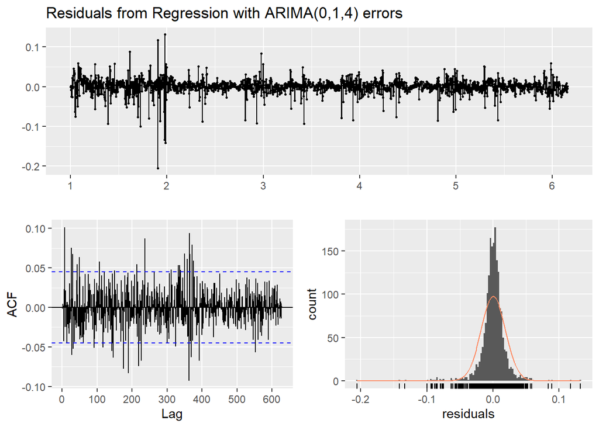

```
##
##  Ljung-Box test
##
## data:  Residuals from Regression with ARIMA(0,1,4) errors
## Q* = 632.11, df = 324, p-value < 2.2e-16
##
## Model df: 53.   Total lags used: 377
```

```r
# import results
atlist<- readRDS("./data/results/forecast_manual/results_AT.rds")
at_fit<- atlist$fit

# see residuals and coeftests
checkresiduals(at_fit)
```

```r
coeftest(at_fit)
```

```
##
## z test of coefficients:
##
##            Estimate  Std. Error  z value  Pr(>|z|)
## ma1     -5.9317e-01  2.3181e-02 -25.5886 < 2.2e-16 ***
## ma2     -2.3765e-01  2.6867e-02  -8.8454 < 2.2e-16 ***
## ma3     -1.4001e-01  2.6305e-02  -5.3228 1.022e-07 ***
## ma4      7.2379e-02  2.6113e-02   2.7718 0.0055748 **
##         -5.2290e-03  2.3880e-04 -21.8966 < 2.2e-16 ***
##          1.0236e-04  7.7743e-06  13.1663 < 2.2e-16 ***
##         -4.7531e-02  1.6961e-03 -28.0232 < 2.2e-16 ***
## S1-7    -4.5699e-02  7.4747e-04 -61.1380 < 2.2e-16 ***
## C1-7    -6.2427e-03  7.4692e-04  -8.3580 < 2.2e-16 ***
## S2-7    -4.7874e-03  5.1338e-04  -9.3253 < 2.2e-16 ***
## C2-7     2.4649e-02  5.1288e-04  48.0597 < 2.2e-16 ***
## S3-7     1.0988e-02  4.3872e-04  25.0463 < 2.2e-16 ***
## C3-7    -1.4056e-03  4.3869e-04  -3.2041 0.0013548 **
## S1-365   8.9897e-03  3.6253e-03   2.4797 0.0131497 *
## C1-365   3.0400e-02  3.8642e-03   7.8671 3.631e-15 ***
## S2-365   4.7552e-03  1.9520e-03   2.4360 0.0148506 *
## C2-365   1.4229e-03  1.9836e-03   0.7173 0.4731602
## S3-365   2.2540e-03  1.4179e-03   1.5896 0.1119159
## C3-365  -1.0929e-02  1.4065e-03  -7.7700 7.852e-15 ***
## S4-365  -5.4965e-03  1.1716e-03  -4.6914 2.714e-06 ***
## C4-365  -5.2616e-03  1.1684e-03  -4.5032 6.692e-06 ***
## S5-365   1.9201e-03  1.0435e-03   1.8401 0.0657482 .
## C5-365  -8.2034e-03  1.0415e-03  -7.8764 3.370e-15 ***
## S6-365   3.2270e-03  9.6698e-04   3.3372 0.0008461 ***
## C6-365  -4.5904e-03  9.6284e-04  -4.7676 1.865e-06 ***
## S7-365   4.0460e-03  9.1604e-04   4.4168 1.002e-05 ***
## C7-365  -6.8842e-03  9.1386e-04  -7.5331 4.954e-14 ***
## S8-365   5.4054e-03  8.8191e-04   6.1292 8.833e-10 ***
## C8-365  -4.4910e-03  8.8168e-04  -5.0936 3.513e-07 ***
## S9-365   6.7224e-04  8.5811e-04   0.7834 0.4333945
## C9-365  -2.8381e-03  8.5622e-04  -3.3147 0.0009174 ***
## S10-365  2.6737e-03  8.4132e-04   3.1779 0.0014833 **
## C10-365 -4.6458e-03  8.3903e-04  -5.5370 3.076e-08 ***
## S11-365  3.6875e-03  8.2679e-04   4.4600 8.195e-06 ***
## C11-365 -4.8546e-03  8.2867e-04  -5.8583 4.675e-09 ***
## S12-365  3.0708e-03  8.1790e-04   3.7545 0.0001737 ***
## C12-365 -3.1028e-03  8.1878e-04  -3.7895 0.0001509 ***
## S13-365  4.9099e-03  8.0964e-04   6.0643 1.325e-09 ***
## C13-365 -2.9453e-03  8.1026e-04  -3.6350 0.0002780 ***
## S14-365  2.1345e-03  8.0414e-04   2.6544 0.0079446 **
## C14-365 -1.3726e-03  8.0511e-04  -1.7049 0.0882216 .
## S15-365  2.7571e-03  7.9791e-04   3.4553 0.0005496 ***
## C15-365 -8.8095e-04  7.9798e-04  -1.1040 0.2696073
## S16-365  1.8853e-03  7.9477e-04   2.3722 0.0176829 *
## C16-365 -1.6948e-03  7.9390e-04  -2.1348 0.0327744 *
## S17-365  2.1443e-03  7.9142e-04   2.7094 0.0067408 **
## C17-365 -4.3715e-04  7.9205e-04  -0.5519 0.5809999
## S18-365  2.1070e-03  7.8873e-04   2.6714 0.0075536 **
## C18-365 -8.9916e-04  7.8808e-04  -1.1410 0.2538898
## S19-365  2.4748e-03  7.8751e-04   3.1426 0.0016744 **
## C19-365  7.9335e-04  7.8603e-04   1.0093 0.3128243
## S20-365  1.5427e-03  7.8650e-04   1.9615 0.0498182 *
## C20-365  1.7174e-03  7.9185e-04   2.1688 0.0300948 *
## ---
## Signif. codes:  0 '***' 0.001 '**' 0.01 '*' 0.05 '.' 0.1 ' ' 1
```

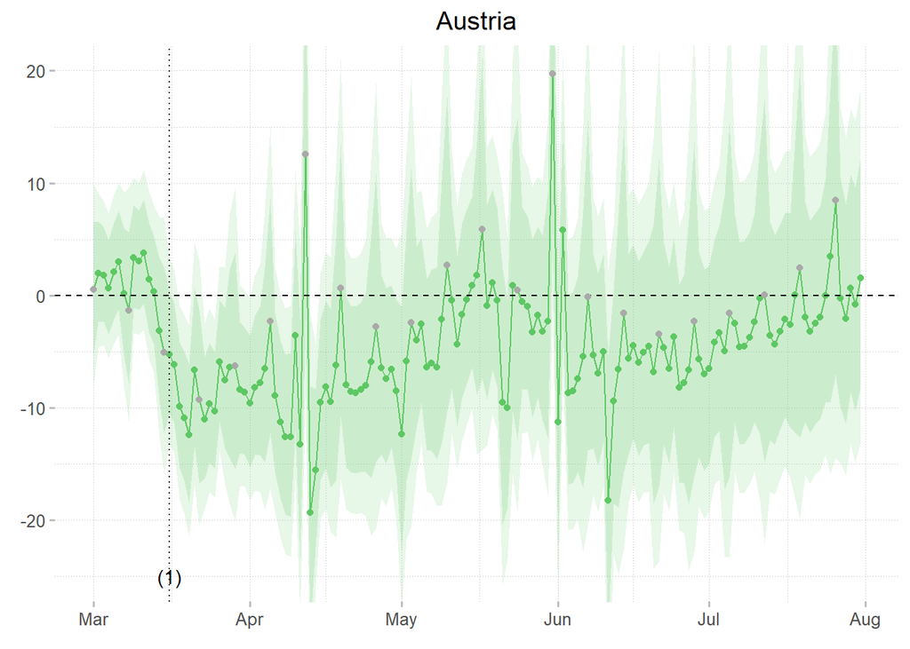

```r
# Plot differences
at_result<- atlist$result %>% mutate(wday = weekdays(date))
at_result$lockdown<- as.Date("2020-03-16")

sunday<- at_result %>% mutate(wday = weekdays(date)) %>% filter(wday == "Sunday")
atplot<- ggplot(at_result, aes(date, dif)) +
  geom_ribbon(aes(date, ymin = diflow80, ymax = difup80), fill = viridis_col[7], alpha = .2) +
  geom_ribbon(aes(date, ymin = diflow95, ymax = difup95), fill = viridis_col[7], alpha = .15) +
  geom_line(color = viridis_col[7]) + geom_point(color = viridis_col[7]) +
  geom_hline(yintercept = 0, linetype = "dashed") +
  geom_vline(xintercept = as.Date("2020-03-16"), linetype = "dotted") +
  annotate("text", x = as.Date("2020-03-16"), y = -25, label = "(1)") +
  # annotate("text", x = as.Date("2020-03-02"), y = -33, label = "-8%", color = "#21908CFF", hjust = 0) +
  #•annotate("text", x = as.Date("2020-03-02"), y = -33, label = "2.9*", hjust = 0) +
  geom_point(data = sunday, aes(date, dif), color = "darkgrey", size = 1.5) +
  coord_cartesian(ylim = c(-25, 20)) +
  labs(x = element_blank(), y = element_blank(), title = "Austria") +
  mytheme() + theme(plot.title = element_text(hjust = 0.5))

write.png(atplot, "./figures/at.png")
```

```r
# Plot absolute values
atplot2<- ggplot(at_result, aes(date, fct)) +
  geom_line(size = .5) +
  geom_ribbon(aes(date, ymin = low80, ymax = up80), alpha = .12) +
  geom_ribbon(aes(date, ymin = low95, ymax = up95), alpha = .08) +
  geom_line(aes(date, actual),  color = viridis_col[7], size = 1) +
  geom_vline(xintercept = as.Date("2020-03-16"), linetype = "dotted") +
  annotate("text", x = as.Date("2020-03-16"), y = .4, label = "(1)") +
  labs(x = element_blank(), y = element_blank(), title = "Austria") +
  coord_cartesian(ylim= c(.4, .8)) +
  mytheme() + theme(plot.title = element_text(hjust = 0.5))
```

This same process is repeated for all individual countries.

```r
############# 4.2 CA ############
# arima
get_arima_results(where = "CA", j = 3, k = 3, p = 4, d = 1, q = 3)
```

```
## [1] 3.00 1.12
```

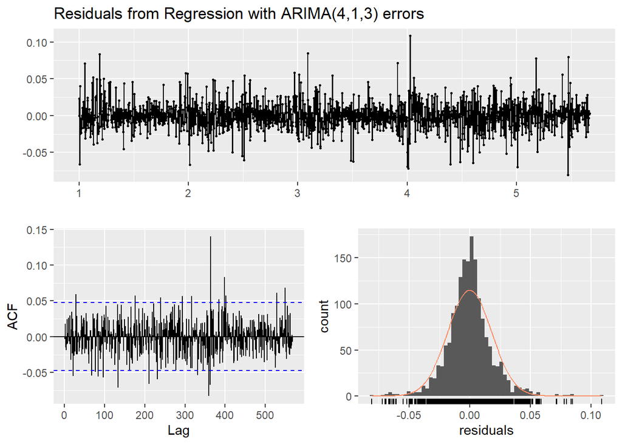

```
##
##  Ljung-Box test
##
## data:  Residuals from Regression with ARIMA(4,1,3) errors
## Q* = 359.38, df = 319, p-value = 0.05915
##
## Model df: 22.   Total lags used: 341
```

```r
calist<- readRDS("./data/results/forecast_manual/results_CA.rds")


ca_fit<- calist$fit
checkresiduals(ca_fit)
```

```r
coeftest(ca_fit)
```

```
##
## z test of coefficients:
##
##           Estimate  Std. Error   z value  Pr(>|z|)
## ar1     1.2005e-01  8.7096e-02    1.3783  0.168108
## ar2    -2.3924e-01  1.5387e-01   -1.5549  0.119980
## ar3     7.0132e-01  1.2566e-01    5.5811 2.389e-08 ***
## ar4    -1.2280e-01  4.5661e-02   -2.6895  0.007156 **
## ma1    -1.3172e-01  8.1205e-02   -1.6221  0.104789
## ma2     3.1267e-02  1.5242e-01    0.2051  0.837463
## ma3    -8.6975e-01  1.1055e-01   -7.8674 3.622e-15 ***
##        -1.6925e-02  1.5204e-04 -111.3217 < 2.2e-16 ***
##         4.5843e-04  1.1075e-05   41.3937 < 2.2e-16 ***
##        -2.0710e-02  1.5562e-03  -13.3077 < 2.2e-16 ***
## S1-7    3.1564e-02  8.9073e-04   35.4358 < 2.2e-16 ***
## C1-7    2.0295e-02  8.9088e-04   22.7807 < 2.2e-16 ***
## S2-7   -1.7663e-02  4.5773e-04  -38.5870 < 2.2e-16 ***
## C2-7    9.4599e-03  4.5498e-04   20.7919 < 2.2e-16 ***
## S3-7   -2.0264e-03  2.9904e-04   -6.7762 1.234e-11 ***
## C3-7   -7.9875e-03  3.0084e-04  -26.5505 < 2.2e-16 ***
## S1-365  4.9935e-02  3.9276e-03   12.7140 < 2.2e-16 ***
## C1-365  4.8098e-02  4.1031e-03   11.7223 < 2.2e-16 ***
## S2-365  3.3885e-02  3.3091e-03   10.2398 < 2.2e-16 ***
## C2-365  2.1746e-02  3.2795e-03    6.6311 3.332e-11 ***
## S3-365  9.3675e-03  3.1678e-03    2.9571  0.003105 **
## C3-365 -9.1647e-03  3.1376e-03   -2.9209  0.003490 **
## ---
## Signif. codes:  0 '***' 0.001 '**' 0.01 '*' 0.05 '.' 0.1 ' ' 1
```

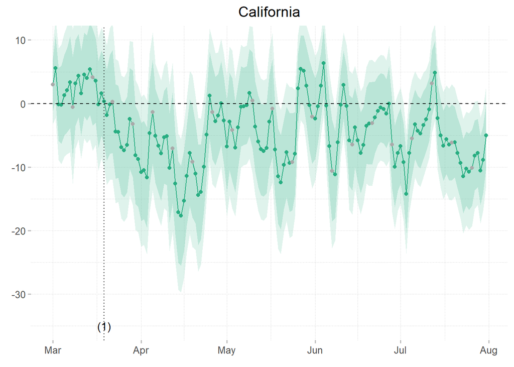

```r
ca_result<- calist$result
ca_result$lockdown<- as.Date("2020-03-19")

sunday<- ca_result %>% mutate(wday = weekdays(date)) %>% filter(wday == "Sunday")
caplot<- ggplot(ca_result, aes(date, dif)) +
  geom_ribbon(aes(date, ymin = diflow80, ymax = difup80), fill = viridis_col[6], alpha = .2) +
  geom_ribbon(aes(date, ymin = diflow95, ymax = difup95), fill = viridis_col[6], alpha = .15) +
  geom_line(color = viridis_col[6]) + geom_point(color = viridis_col[6]) +
  geom_hline(yintercept = 0, linetype = "dashed") +
  geom_vline(xintercept = as.Date("2020-03-19"), linetype = "dotted") +
  annotate("text", x = as.Date("2020-03-19"), y = -35, label = "(1)") +
  #annotate("text", x = as.Date("2020-03-02"), y = -23, label = "1.8*", hjust = 0) +
  geom_point(data = sunday, aes(date, dif), color = "darkgrey", size = 1.5) +
  coord_cartesian(ylim = c(-35, 10)) +
  labs(x = element_blank(), y = element_blank(), title = "California") +
  mytheme() + theme(plot.title = element_text(hjust = 0.5))

write.png(caplot, "./figures/ca.png")
```

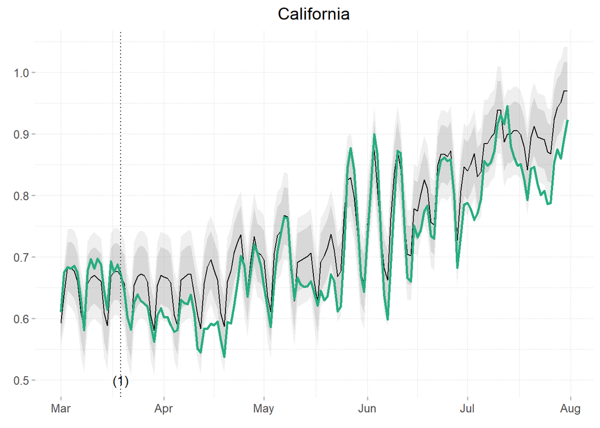

```r
caplot2<- ggplot(ca_result, aes(date, fct)) +
  geom_line(size = .5) +
  geom_ribbon(aes(date, ymin = low80, ymax = up80), alpha = .12) +
  geom_ribbon(aes(date, ymin = low95, ymax = up95), alpha = .08) +
  geom_line(aes(date, actual),  color = viridis_col[6], size = 1) +
  geom_vline(xintercept = as.Date("2020-03-19"), linetype = "dotted") +
  annotate("text", x = as.Date("2020-03-19"), y = .5, label = "(1)") +
  labs(x = element_blank(), y = element_blank(), title = "California") +
  mytheme() + theme(plot.title = element_text(hjust = 0.5))

write.png(caplot2, "./figures/ca2.png")
```

```r
############# 4.3 DE ############
get_arima_results(where = "DE", j = 3, k = 11, p = 4, d = 1, q = 1) # get_results2(where = "DE")
```

```
## [1] 11.00  0.81
```

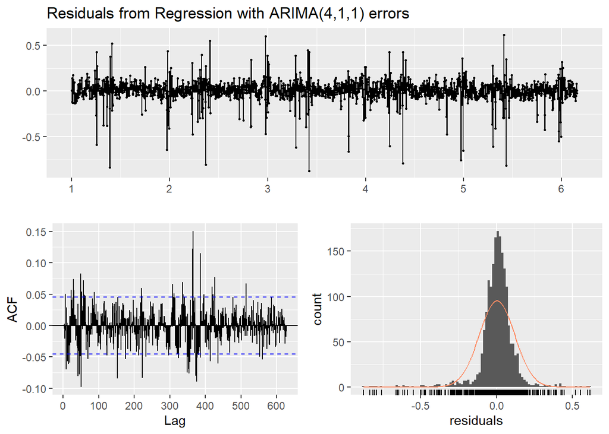

```
##
##  Ljung-Box test
##
## data:  Residuals from Regression with ARIMA(4,1,1) errors
## Q* = 798.98, df = 341, p-value < 2.2e-16
##
## Model df: 36.   Total lags used: 377
```

```r
delist<- readRDS("./data/results/forecast_manual/results_DE.rds")

de_fit<- delist$fit
checkresiduals(de_fit)
```

```r
coeftest(de_fit)
```

```
##
## z test of coefficients:
##
##            Estimate  Std. Error   z value  Pr(>|z|)
## ar1      5.2816e-01  4.4865e-02   11.7721 < 2.2e-16 ***
## ar2     -7.0598e-02  3.7333e-02   -1.8911 0.0586167 .
## ar3      8.5387e-02  3.2416e-02    2.6341 0.0084356 **
## ar4     -4.9942e-02  2.3896e-02   -2.0900 0.0366181 *
## ma1     -9.8668e-01  3.5914e-03 -274.7327 < 2.2e-16 ***
##         -1.4522e-02  1.1306e-02   -1.2845 0.1989838
##          3.5937e-04  8.5219e-05    4.2170 2.476e-05 ***
##         -5.0879e-01  7.1921e-02   -7.0744 1.501e-12 ***
## S1-7    -4.3234e-01  4.7709e-03  -90.6201 < 2.2e-16 ***
## C1-7    -4.7284e-02  4.7419e-03   -9.9716 < 2.2e-16 ***
## S2-7    -3.6596e-02  3.6766e-03   -9.9537 < 2.2e-16 ***
## C2-7     2.3586e-01  3.3699e-03   69.9896 < 2.2e-16 ***
## S3-7     9.9880e-02  2.3865e-03   41.8520 < 2.2e-16 ***
## C3-7    -1.2659e-02  2.4148e-03   -5.2423 1.586e-07 ***
## S1-365   3.5246e-02  1.1771e-02    2.9944 0.0027500 **
## C1-365   1.8738e-01  4.1105e-02    4.5586 5.150e-06 ***
## S2-365   6.5692e-03  1.0147e-02    0.6474 0.5173553
## C2-365   1.1093e-02  1.3575e-02    0.8171 0.4138598
## S3-365   1.1731e-02  7.7512e-03    1.5134 0.1301841
## C3-365  -9.0425e-02  8.2058e-03  -11.0197 < 2.2e-16 ***
## S4-365  -9.9848e-03  7.9183e-03   -1.2610 0.2073161
## C4-365  -4.9527e-02  8.5144e-03   -5.8169 5.995e-09 ***
## S5-365   1.1443e-02  7.5825e-03    1.5092 0.1312537
## C5-365  -6.7290e-02  8.1527e-03   -8.2537 < 2.2e-16 ***
## S6-365   3.2422e-02  8.0654e-03    4.0198 5.824e-05 ***
## C6-365  -4.0881e-02  7.4857e-03   -5.4612 4.730e-08 ***
## S7-365   3.3877e-02  8.5170e-03    3.9776 6.960e-05 ***
## C7-365  -5.7002e-02  7.8652e-03   -7.2474 4.250e-13 ***
## S8-365   3.6553e-02  7.5391e-03    4.8485 1.244e-06 ***
## C8-365  -4.1501e-02  7.7660e-03   -5.3439 9.098e-08 ***
## S9-365   2.9891e-02  7.6255e-03    3.9199 8.858e-05 ***
## C9-365  -1.9624e-02  7.3916e-03   -2.6549 0.0079334 **
## S10-365  2.3993e-02  7.3817e-03    3.2504 0.0011524 **
## C10-365 -2.1729e-02  7.3530e-03   -2.9551 0.0031262 **
## S11-365  2.9777e-02  7.4519e-03    3.9958 6.447e-05 ***
## C11-365 -2.6109e-02  7.3700e-03   -3.5426 0.0003962 ***
## ---
## Signif. codes:  0 '***' 0.001 '**' 0.01 '*' 0.05 '.' 0.1 ' ' 1
```

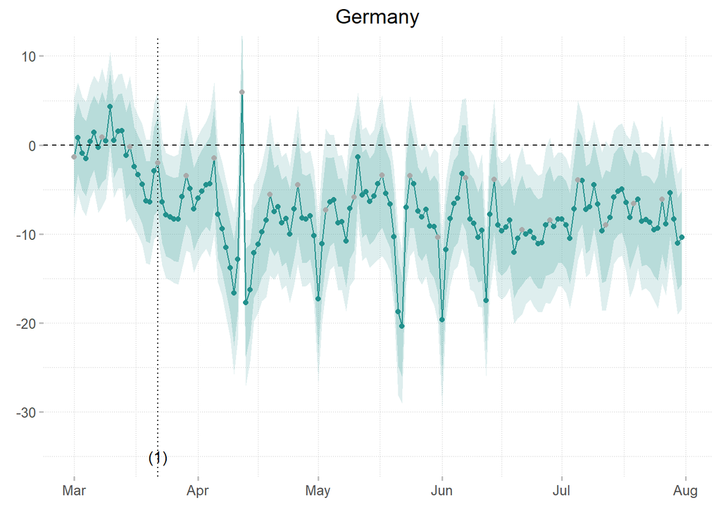

```r
de_result<- delist$result
de_result$lockdown<- as.Date("2020-03-22")

sunday<- de_result %>% mutate(wday = weekdays(date)) %>% filter(wday == "Sunday")
deplot<- ggplot(de_result, aes(date, dif)) +
  geom_ribbon(aes(date, ymin = diflow80, ymax = difup80), fill = viridis_col[5], alpha = .2) +
  geom_ribbon(aes(date, ymin = diflow95, ymax = difup95), fill = viridis_col[5], alpha = .15) +
  geom_line(color =viridis_col[5]) + geom_point(color = viridis_col[5]) +
  geom_hline(yintercept = 0, linetype = "dashed") +
  geom_vline(xintercept = as.Date("2020-03-22"), linetype = "dotted") +
  annotate("text", x = as.Date("2020-03-22"), y = -35, label = "(1)") +
  #annotate("text", x = as.Date("2020-03-02"), y = -23, label = "1.8*", hjust = 0) +
  geom_point(data = sunday, aes(date, dif), color = "darkgrey", size = 1.5) +
  coord_cartesian(ylim = c(-35, 10)) +
  labs(x = element_blank(), y = element_blank(), title = "Germany") +
  mytheme() + theme(plot.title = element_text(hjust = 0.5))

write.png(deplot, "./figures/de.png")
```

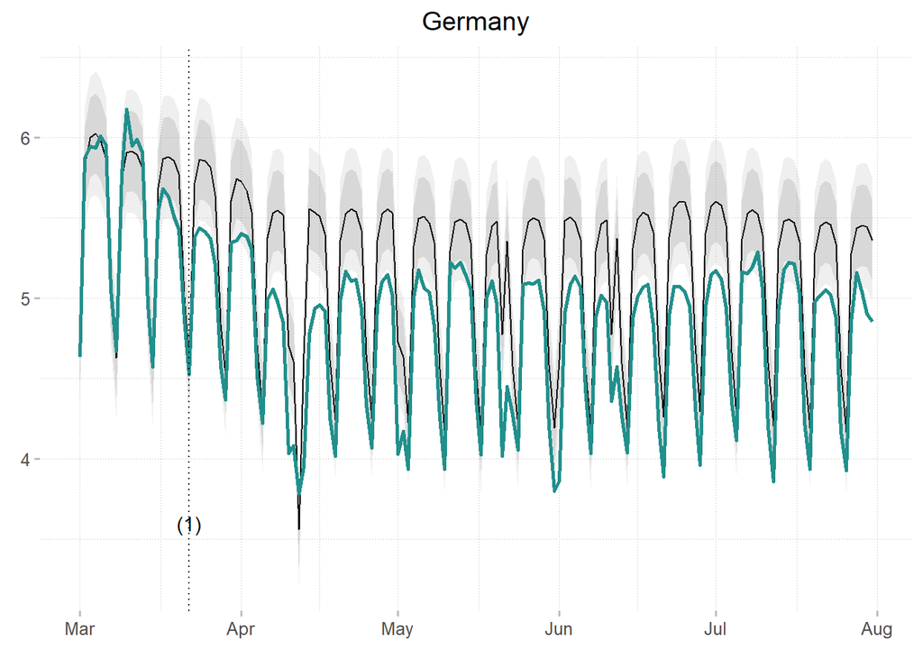

```r
deplot2<- ggplot(de_result, aes(date, fct)) +
  geom_line(size = .5) +
  geom_ribbon(aes(date, ymin = low80, ymax = up80), alpha = .12) +
  geom_ribbon(aes(date, ymin = low95, ymax = up95), alpha = .08) +
  geom_line(aes(date, actual),  color = viridis_col[5], size = 1) +
  geom_vline(xintercept = as.Date("2020-03-22"), linetype = "dotted") +
  annotate("text", x = as.Date("2020-03-22"), y = 3.6, label = "(1)") +
  labs(x = element_blank(), y = element_blank(), title = "Germany") +
  mytheme() + theme(plot.title = element_text(hjust = 0.5))

write.png(deplot2, "./figures/de2.png")
```

```r
############# 4.4 ES ############
get_arima_results(where = "ES", j=3, k = 23, p = 3, d = 1, q = 2)
```

```
## [1] 23.00 -0.07
```

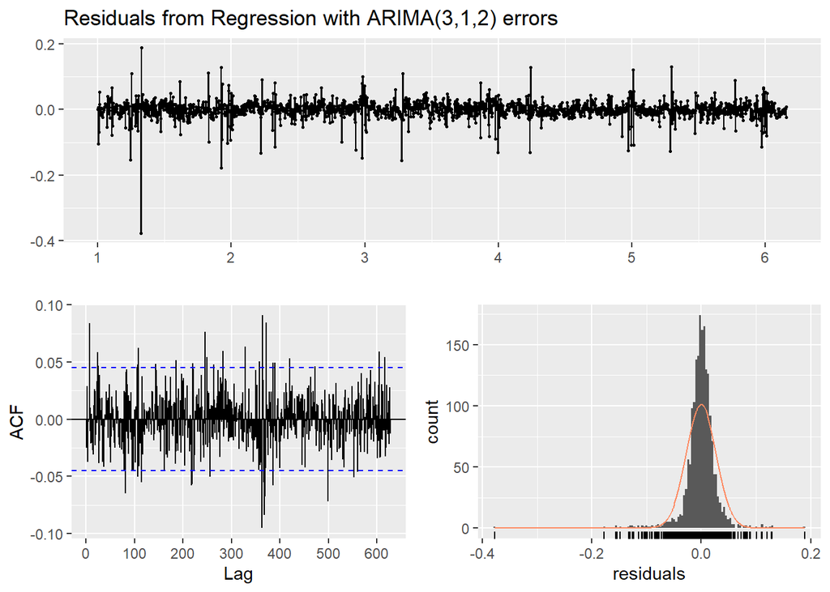

```
##
##  Ljung-Box test
##
## data:  Residuals from Regression with ARIMA(3,1,2) errors
## Q* = 551.17, df = 317, p-value = 7.105e-15
##
## Model df: 60.   Total lags used: 377
```

```r
eslist<- readRDS("./data/results/forecast_manual/results_ES.rds")

es_fit<- eslist$fit
checkresiduals(es_fit)
```

```r
coeftest(es_fit)
```

```
##
## z test of coefficients:
##
##            Estimate  Std. Error  z value  Pr(>|z|)
## ar1      1.3670e+00  5.4783e-02  24.9540 < 2.2e-16 ***
## ar2     -5.1167e-01  4.6985e-02 -10.8901 < 2.2e-16 ***
## ar3      7.1618e-02  2.5156e-02   2.8470 0.0044138 **
## ma1     -1.7510e+00  4.9336e-02 -35.4908 < 2.2e-16 ***
## ma2      7.5317e-01  4.9308e-02  15.2748 < 2.2e-16 ***
##         -1.5430e-02  3.4222e-04 -45.0874 < 2.2e-16 ***
##          3.7102e-04  1.9098e-05  19.4274 < 2.2e-16 ***
##         -1.2442e-01  3.3283e-03 -37.3830 < 2.2e-16 ***
## S1-7    -8.2090e-02  1.1483e-03 -71.4886 < 2.2e-16 ***
## C1-7    -4.9353e-03  1.1483e-03  -4.2977 1.725e-05 ***
## S2-7    -2.8767e-03  7.1855e-04  -4.0034 6.244e-05 ***
## C2-7     4.8112e-02  7.1849e-04  66.9625 < 2.2e-16 ***
## S3-7     2.2631e-02  5.4510e-04  41.5164 < 2.2e-16 ***
## C3-7    -4.4981e-03  5.4662e-04  -8.2289 < 2.2e-16 ***
## S1-365   1.6658e-03  3.5534e-03   0.4688 0.6392166
## C1-365   2.2355e-02  4.3577e-03   5.1301 2.897e-07 ***
## S2-365   3.0224e-02  3.0309e-03   9.9721 < 2.2e-16 ***
## C2-365   3.3239e-02  2.9691e-03  11.1950 < 2.2e-16 ***
## S3-365  -3.9153e-03  2.8009e-03  -1.3979 0.1621549
## C3-365  -1.6056e-02  2.7812e-03  -5.7731 7.783e-09 ***
## S4-365   4.6309e-04  2.6740e-03   0.1732 0.8625071
## C4-365  -3.5039e-03  2.6642e-03  -1.3152 0.1884537
## S5-365   2.8964e-03  2.5525e-03   1.1347 0.2564939
## C5-365  -1.8861e-02  2.5531e-03  -7.3874 1.497e-13 ***
## S6-365   1.4177e-02  2.4440e-03   5.8005 6.612e-09 ***
## C6-365  -7.5879e-03  2.4361e-03  -3.1148 0.0018407 **
## S7-365   2.2291e-03  2.3368e-03   0.9539 0.3401438
## C7-365  -8.1068e-03  2.3304e-03  -3.4786 0.0005040 ***
## S8-365   9.8117e-03  2.2345e-03   4.3910 1.128e-05 ***
## C8-365  -7.9169e-03  2.2361e-03  -3.5405 0.0003993 ***
## S9-365   6.4904e-03  2.1473e-03   3.0225 0.0025066 **
## C9-365  -2.3595e-03  2.1448e-03  -1.1001 0.2712937
## S10-365  4.3734e-04  2.0695e-03   0.2113 0.8326327
## C10-365 -8.9462e-03  2.0648e-03  -4.3327 1.473e-05 ***
## S11-365  8.1117e-03  1.9949e-03   4.0663 4.777e-05 ***
## C11-365 -5.3640e-03  1.9948e-03  -2.6890 0.0071675 **
```

[output cut: 11 more lines]

```
## C17-365 -9.7299e-04  1.7053e-03  -0.5706 0.5682891
## S18-365  2.8549e-03  1.6658e-03   1.7138 0.0865660 .
## C18-365 -1.8261e-03  1.6684e-03  -1.0945 0.2737197
## S19-365  5.9603e-03  1.6372e-03   3.6406 0.0002720 ***
## C19-365  1.0138e-03  1.6340e-03   0.6205 0.5349526
## S20-365  5.3503e-03  1.6099e-03   3.3235 0.0008890 ***
## C20-365  2.3305e-03  1.6076e-03   1.4497 0.1471515
## S21-365  4.3275e-03  1.5833e-03   2.7333 0.0062710 **
## C21-365  3.0497e-04  1.5819e-03   0.1928 0.8471211
## S22-365 -2.2330e-03  1.5611e-03  -1.4304 0.1525928
## C22-365  2.3593e-03  1.5592e-03   1.5132 0.1302249
## S23-365  1.4515e-03  1.5384e-03   0.9435 0.3454320
## C23-365  3.0887e-03  1.5361e-03   2.0108 0.0443512 *
## ---
## Signif. codes:  0 '***' 0.001 '**' 0.01 '*' 0.05 '.' 0.1 ' ' 1
```

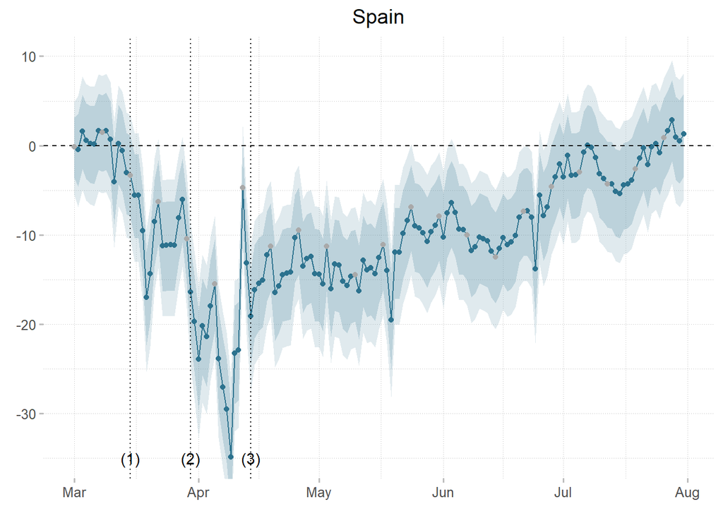

```r
es_result<- eslist$result
es_result$lockdown<- as.Date("2020-03-15")


sunday<- es_result %>% mutate(wday = weekdays(date)) %>% filter(wday == "Sunday")
esplot<- ggplot(es_result, aes(date, dif)) +
  geom_ribbon(aes(date, ymin = diflow80, ymax = difup80), fill = viridis_col[4], alpha = .2) +
  geom_ribbon(aes(date, ymin = diflow95, ymax = difup95), fill = viridis_col[4], alpha = .15) +
  geom_line(color = viridis_col[4]) + geom_point(color = viridis_col[4]) +
  geom_hline(yintercept = 0, linetype = "dashed") +
  geom_vline(xintercept = as.Date("2020-03-15"), linetype = "dotted") +
  geom_vline(xintercept = as.Date("2020-03-30"), linetype = "dotted") +
  geom_vline(xintercept = as.Date("2020-04-14"), linetype = "dotted") +
  annotate("text", x = as.Date("2020-03-15"), y = -35, label = "(1)") +
  annotate("text", x = as.Date("2020-03-30"), y = -35, label = "(2)") +
  annotate("text", x = as.Date("2020-04-14"), y = -35, label = "(3)") +
  #annotate("text", x = as.Date("2020-03-02"), y = -43, label = "1.63*", hjust = 0) +
  geom_point(data = sunday, aes(date, dif), color = "darkgrey", size = 1.5) +
  coord_cartesian(ylim = c(-35, 10)) +
  labs(x = element_blank(), y = element_blank(), title = "Spain") +
  mytheme() + theme(plot.title = element_text(hjust = 0.5))

write.png(esplot, "./figures/es.png")
```

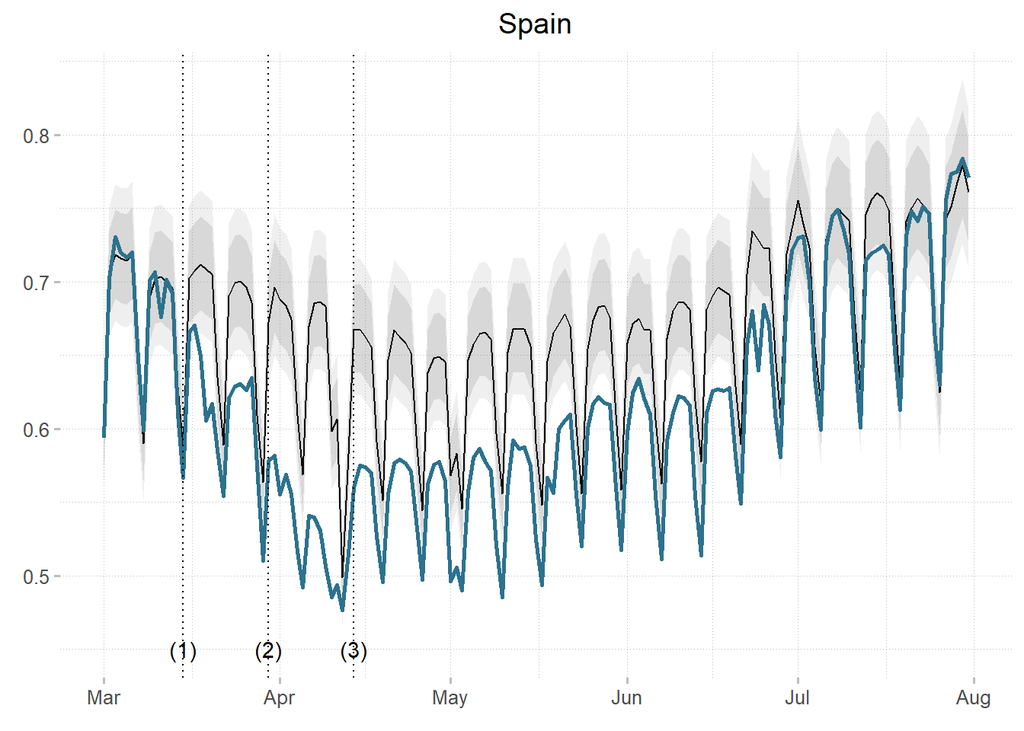

```r
esplot2<- ggplot(es_result, aes(date, fct)) +
  geom_line(size = .5) +
  geom_ribbon(aes(date, ymin = low80, ymax = up80), alpha = .12) +
  geom_ribbon(aes(date, ymin = low95, ymax = up95), alpha = .08) +
  geom_line(aes(date, actual),  color = viridis_col[4], size = 1) +
  geom_vline(xintercept = as.Date("2020-03-15"), linetype = "dotted") +
  geom_vline(xintercept = as.Date("2020-03-30"), linetype = "dotted") +
  geom_vline(xintercept = as.Date("2020-04-14"), linetype = "dotted") +
  annotate("text", x = as.Date("2020-03-15"), y = .45, label = "(1)") +
  annotate("text", x = as.Date("2020-03-30"), y = .45, label = "(2)") +
  annotate("text", x = as.Date("2020-04-14"), y = .45, label = "(3)") +
  labs(x = element_blank(), y = element_blank(), title = "Spain") +
  mytheme() + theme(plot.title = element_text(hjust = 0.5))

write.png(esplot2, "./figures/es2.png")
```

```r
############# 4.5 FL ############
get_arima_results(where = "FL", j = 3, k = 3, p = 1, d = 1, q = 2) # get_results2(where = "FL")
```

```
## [1] 3.00 1.03
```

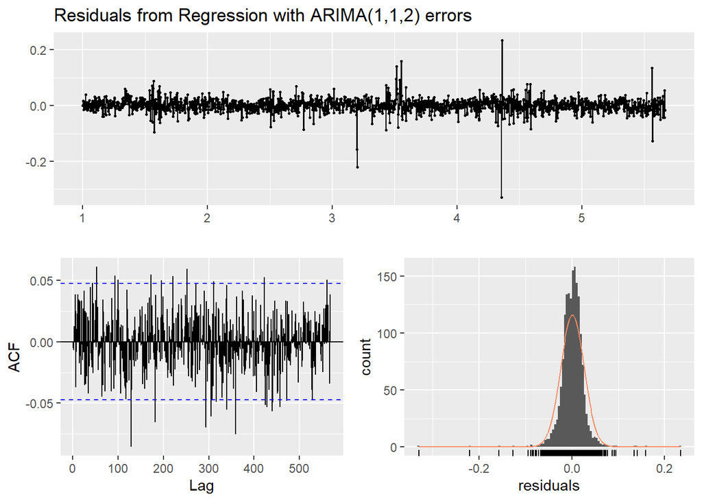

```
##
##  Ljung-Box test
##
## data:  Residuals from Regression with ARIMA(1,1,2) errors
## Q* = 364.57, df = 323, p-value = 0.05523
##
## Model df: 18.   Total lags used: 341
```

```r
fllist<- readRDS("./data/results/forecast_manual/results_FL.rds")

fl_fit<- fllist$fit
checkresiduals(fl_fit)
```

```r
coeftest(fl_fit)
```

```
##
## z test of coefficients:
##
##           Estimate  Std. Error   z value  Pr(>|z|)
## ar1     0.56802920  0.02684292   21.1612 < 2.2e-16 ***
## ma1    -0.62729157  0.03088317  -20.3118 < 2.2e-16 ***
## ma2    -0.36917782  0.03028660  -12.1895 < 2.2e-16 ***
##        -0.03410753  0.00025652 -132.9619 < 2.2e-16 ***
##         0.00084874  0.00001660   51.1288 < 2.2e-16 ***
##        -0.00340945  0.00213808   -1.5946  0.110794
## S1-7    0.01214026  0.00138959    8.7366 < 2.2e-16 ***
## C1-7    0.00996577  0.00138957    7.1718 7.399e-13 ***
## S2-7   -0.00784903  0.00067965  -11.5486 < 2.2e-16 ***
## C2-7    0.00147979  0.00067656    2.1872  0.028726 *
## S3-7   -0.00061973  0.00038580   -1.6064  0.108196
## C3-7   -0.00194470  0.00038896   -4.9998 5.740e-07 ***
## S1-365  0.02822526  0.00297386    9.4911 < 2.2e-16 ***
## C1-365  0.04567321  0.00341057   13.3917 < 2.2e-16 ***
## S2-365  0.01108728  0.00274741    4.0355 5.448e-05 ***
## C2-365  0.00794100  0.00275335    2.8841  0.003925 **
## S3-365 -0.01114419  0.00274026   -4.0668 4.766e-05 ***
## C3-365 -0.00336776  0.00271963   -1.2383  0.215600
## ---
## Signif. codes:  0 '***' 0.001 '**' 0.01 '*' 0.05 '.' 0.1 ' ' 1
```

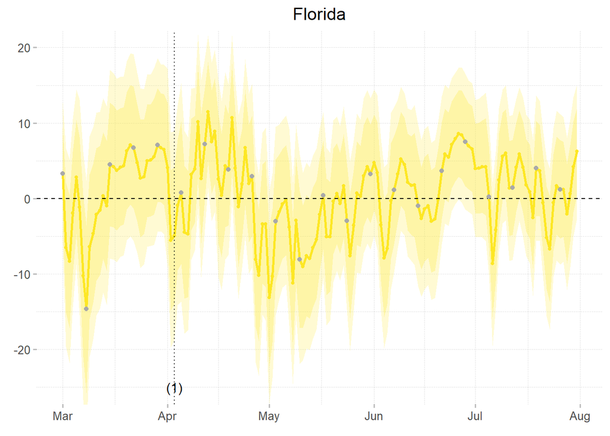

```r
fl_result<- fllist$result
fl_result$lockdown<- as.Date("2020-04-03")

sunday<- fl_result %>% mutate(wday = weekdays(date)) %>% filter(wday == "Sunday")
flplot<- ggplot(fl_result, aes(date, dif)) +
  geom_ribbon(aes(date, ymin = diflow80, ymax = difup80), fill = viridis_col[9], alpha = .25) +
  geom_ribbon(aes(date, ymin = diflow95, ymax = difup95), fill = viridis_col[9], alpha = .2) +
  geom_line(color = viridis_col[9], size = 1) + geom_point(color = viridis_col[9], size = 1) +
  geom_hline(yintercept = 0, linetype = "dashed") +
  geom_vline(xintercept = as.Date("2020-04-03"), linetype = "dotted") +
  annotate("text", x = as.Date("2020-04-03"), y = -25, label = "(1)") +
  #annotate("text", x = as.Date("2020-03-02"), y = -23, label = "2.71*", hjust = 0) +
  geom_point(data = sunday, aes(date, dif), color = "darkgrey", size = 1.5) +
  coord_cartesian(ylim = c(-25, 20)) +
  labs(x = element_blank(), y = element_blank(), title = "Florida") +
  mytheme()+ theme(plot.title = element_text(hjust = 0.5))

write.png(flplot, "./figures/fl.png")
```

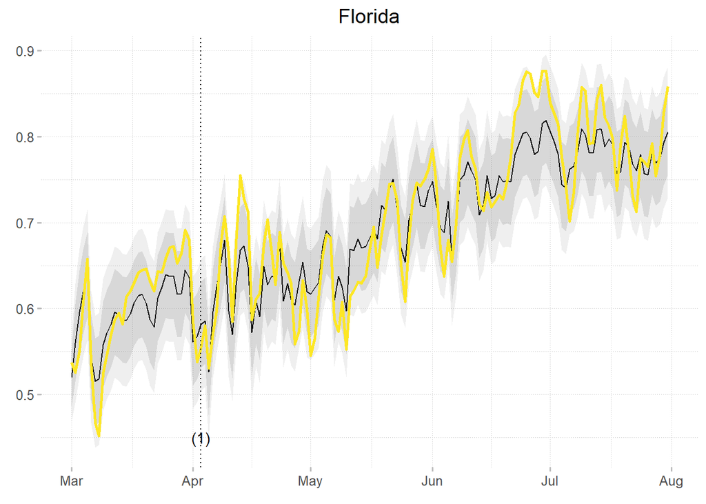

```r
flplot2<- ggplot(fl_result, aes(date, fct)) +
  geom_line(size = .5) +
  geom_ribbon(aes(date, ymin = low80, ymax = up80), alpha = .12) +
  geom_ribbon(aes(date, ymin = low95, ymax = up95), alpha = .08) +
  geom_line(aes(date, actual),  color = viridis_col[9], size = 1) +
  geom_vline(xintercept = as.Date("2020-04-03"), linetype = "dotted") +
  annotate("text", x = as.Date("2020-04-03"), y = .45, label = "(1)") +
  labs(x = element_blank(), y = element_blank(), title = "Florida") +
  mytheme() + theme(plot.title = element_text(hjust = 0.5))

write.png(flplot2, "./figures/fl2.png")
```

```r
############# 4.6 FR ############
get_arima_results(where = "FR", j = 3, k = 19, p = 7, d = 1, q = 6)
```

```
## [1] 19 -1
```

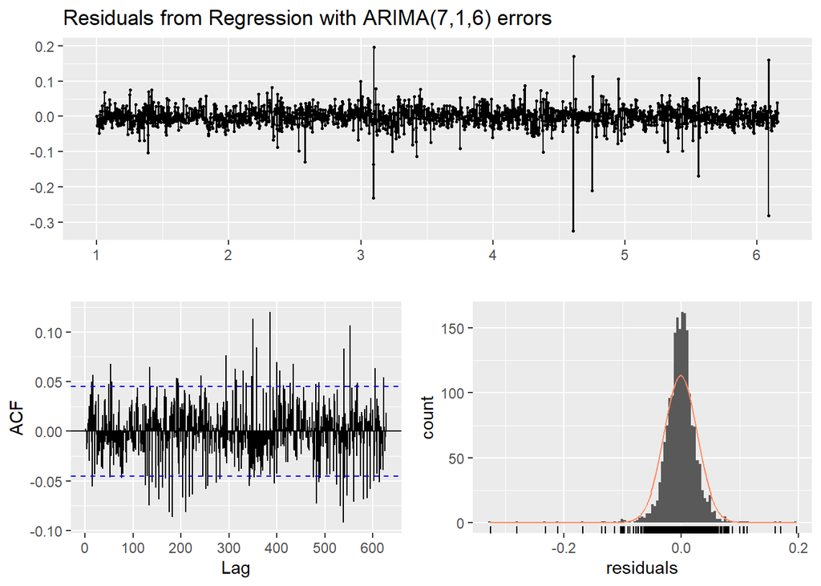

```
##
##  Ljung-Box test
##
## data:  Residuals from Regression with ARIMA(7,1,6) errors
## Q* = 643.3, df = 317, p-value < 2.2e-16
##
## Model df: 60.   Total lags used: 377
```

```r
frlist<- readRDS("./data/results/forecast_manual/results_FR.rds")


fr_fit<- frlist$fit
checkresiduals(fr_fit)
```

```r
coeftest(fr_fit)
```

```
##
## z test of coefficients:
##
##            Estimate  Std. Error  z value  Pr(>|z|)
## ar1      4.1571e-01  6.2065e-02   6.6979 2.115e-11 ***
## ar2     -5.3241e-01  7.9485e-02  -6.6982 2.110e-11 ***
## ar3      8.5433e-02  1.0017e-01   0.8529  0.393705
## ar4     -6.7897e-02  8.8660e-02  -0.7658  0.443788
## ar5     -4.0229e-01  7.5058e-02  -5.3597 8.338e-08 ***
## ar6      3.6176e-01  3.7745e-02   9.5844 < 2.2e-16 ***
## ar7      2.4043e-01  2.5570e-02   9.4029 < 2.2e-16 ***
## ma1     -8.7844e-01  6.0861e-02 -14.4336 < 2.2e-16 ***
## ma2      5.5660e-01  1.0161e-01   5.4779 4.303e-08 ***
## ma3     -3.4341e-01  1.1986e-01  -2.8649  0.004171 **
## ma4     -7.0019e-02  1.1755e-01  -0.5957  0.551409
## ma5      3.6671e-01  8.9410e-02   4.1014 4.106e-05 ***
## ma6     -6.2233e-01  5.2407e-02 -11.8749 < 2.2e-16 ***
##         -1.5505e-02  2.9993e-04 -51.6965 < 2.2e-16 ***
##          3.0945e-04  1.3894e-05  22.2718 < 2.2e-16 ***
##         -6.2114e-02  3.0235e-03 -20.5434 < 2.2e-16 ***
## S1-7    -6.0714e-02  3.3118e-03 -18.3324 < 2.2e-16 ***
## C1-7    -1.9386e-03  3.3102e-03  -0.5856  0.558115
## S2-7    -3.4884e-03  1.9731e-03  -1.7680  0.077064 .
## C2-7     3.3680e-02  1.9888e-03  16.9348 < 2.2e-16 ***
## S3-7     1.3372e-02  7.0482e-04  18.9723 < 2.2e-16 ***
## C3-7    -1.3933e-03  7.0478e-04  -1.9769  0.048051 *
## S1-365   4.2188e-02  3.2439e-03  13.0053 < 2.2e-16 ***
## C1-365   1.3124e-01  3.7321e-03  35.1655 < 2.2e-16 ***
## S2-365   1.9417e-03  3.0897e-03   0.6284  0.529715
## C2-365   1.6325e-02  3.1011e-03   5.2644 1.407e-07 ***
## S3-365  -6.3655e-03  3.0267e-03  -2.1031  0.035453 *
## C3-365  -2.2835e-02  3.0156e-03  -7.5722 3.669e-14 ***
## S4-365  -4.0039e-03  2.9673e-03  -1.3493  0.177226
## C4-365   4.7720e-03  2.9561e-03   1.6143  0.106463
## S5-365   7.3511e-04  2.8910e-03   0.2543  0.799282
## C5-365  -1.6680e-02  2.8941e-03  -5.7635 8.240e-09 ***
## S6-365   1.2095e-02  2.8187e-03   4.2910 1.778e-05 ***
## C6-365   3.7197e-03  2.8132e-03   1.3222  0.186091
## S7-365  -3.8476e-03  2.7362e-03  -1.4062  0.159676
## C7-365  -5.6522e-03  2.7281e-03  -2.0718  0.038282 *
```

[output cut: 11 more lines]

```
## C13-365 -3.3708e-03  2.2097e-03  -1.5255  0.127138
## S14-365  1.4591e-03  2.1304e-03   0.6849  0.493403
## C14-365  1.9880e-03  2.1318e-03   0.9325  0.351056
## S15-365 -2.3975e-03  2.0540e-03  -1.1673  0.243106
## C15-365  2.1053e-03  2.0524e-03   1.0258  0.304998
## S16-365  3.7012e-03  1.9820e-03   1.8674  0.061852 .
## C16-365  1.2558e-03  1.9816e-03   0.6337  0.526267
## S17-365  2.7282e-04  1.9119e-03   0.1427  0.886531
## C17-365  2.4328e-03  1.9147e-03   1.2706  0.203882
## S18-365 -1.0497e-03  1.8448e-03  -0.5690  0.569350
## C18-365  4.2050e-03  1.8448e-03   2.2794  0.022643 *
## S19-365  5.6687e-03  1.7847e-03   3.1762  0.001492 **
## C19-365  3.6763e-03  1.7806e-03   2.0647  0.038949 *
## ---
## Signif. codes:  0 '***' 0.001 '**' 0.01 '*' 0.05 '.' 0.1 ' ' 1
```

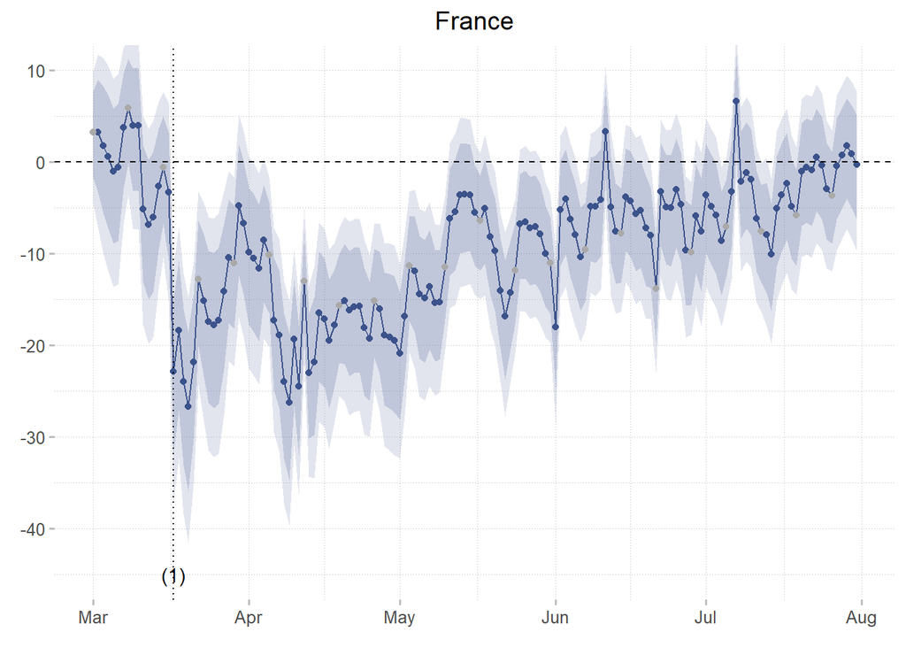

```r
fr_result<- frlist$result
fr_result$lockdown<- as.Date("2020-03-17")

sunday<- fr_result %>% mutate(wday = weekdays(date)) %>% filter(wday == "Sunday")
frplot<- ggplot(fr_result, aes(date, dif)) +
  geom_ribbon(aes(date, ymin = diflow80, ymax = difup80), fill = viridis_col[3], alpha = .2) +
  geom_ribbon(aes(date, ymin = diflow95, ymax = difup95), fill = viridis_col[3], alpha = .15) +
  geom_line(color = viridis_col[3]) + geom_point(color = viridis_col[3]) +
  geom_hline(yintercept = 0, linetype = "dashed") +
  geom_vline(xintercept = as.Date("2020-03-17"), linetype = "dotted") +
  annotate("text", x = as.Date("2020-03-17"), y = -45, label = "(1)") +
  #annotate("text", x = as.Date("2020-03-02"), y = -43, label = "2.29*", hjust = 0) +
  geom_point(data = sunday, aes(date, dif), color = "darkgrey", size = 1.5) +
  coord_cartesian(ylim = c(-45, 10)) +
  labs(x = element_blank(), y = element_blank(), title = "France") +
  mytheme() + theme(plot.title = element_text(hjust = 0.5))

write.png(frplot, "./figures/fr.png")
```

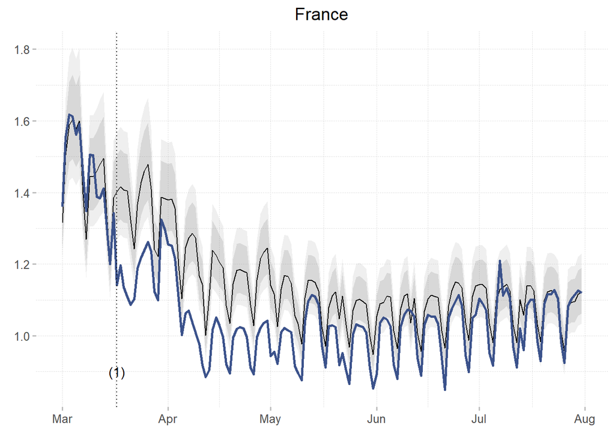

```r
frplot2<- ggplot(fr_result, aes(date, fct)) +
  geom_line(size = .5) +
  geom_ribbon(aes(date, ymin = low80, ymax = up80), alpha = .12) +
  geom_ribbon(aes(date, ymin = low95, ymax = up95), alpha = .08) +
  geom_line(aes(date, actual),  color = viridis_col[3], size = 1) +
  geom_vline(xintercept = as.Date("2020-03-17"), linetype = "dotted") +
  labs(x = element_blank(), y = element_blank(), title = "France") +
  annotate("text", x = as.Date("2020-03-17"), y = .9, label = "(1)") +
  mytheme() + theme(plot.title = element_text(hjust = 0.5))

write.png(frplot2, "./figures/fr2.png")
```

```r
############# 4.7 GB ############
get_arima_results(where = "GB",j = 3, k = 3, p = 2, d = 1, q = 1) # get_results2(where = "UK")
```

```
## [1] 3.0 1.2
```

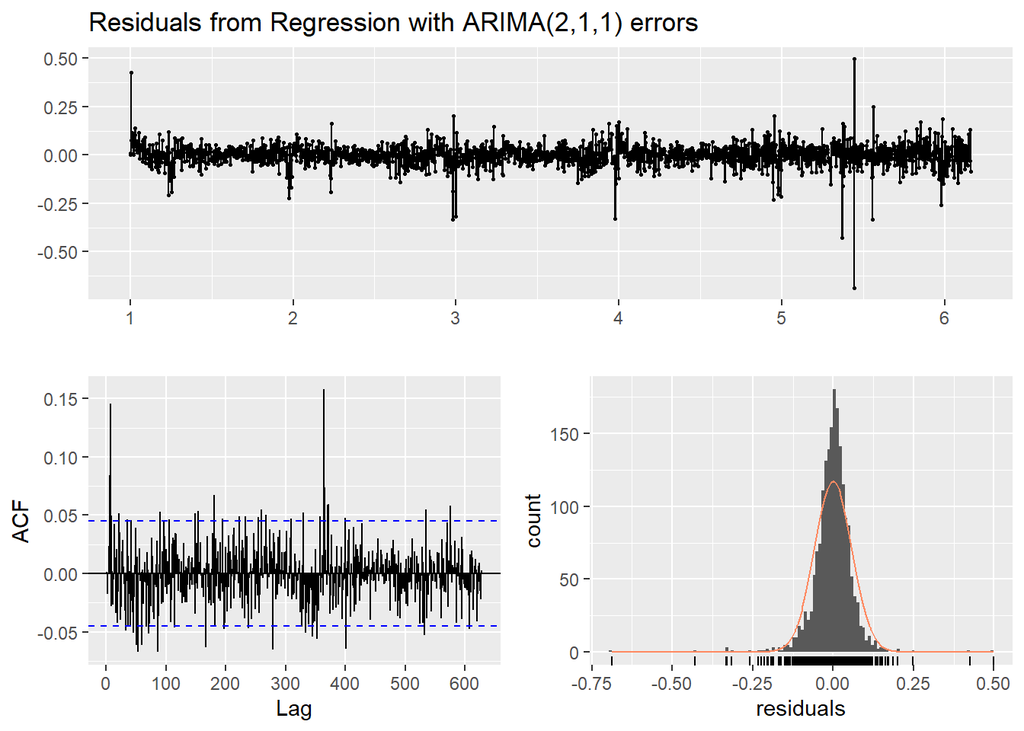

```
##
##  Ljung-Box test
##
## data:  Residuals from Regression with ARIMA(2,1,1) errors
## Q* = 629.69, df = 359, p-value < 2.2e-16
##
## Model df: 18.   Total lags used: 377
```

```r
gblist<- readRDS("./data/results/forecast_manual/results_GB.rds")

gb_fit<- gblist$fit
checkresiduals(gb_fit)
```

```r
coeftest(gb_fit)
```

```
##
## z test of coefficients:
##
##           Estimate  Std. Error  z value  Pr(>|z|)
## ar1     0.60523138  0.05245679  11.5377 < 2.2e-16 ***
## ar2     0.04041454  0.03009927   1.3427 0.1793664
## ma1    -0.96697216  0.02242680 -43.1168 < 2.2e-16 ***
##        -0.02773800  0.00920335  -3.0139 0.0025791 **
##         0.00067328  0.00011727   5.7412 9.403e-09 ***
##        -0.13229515  0.02752255  -4.8068 1.534e-06 ***
## S1-7   -0.10543976  0.00229781 -45.8871 < 2.2e-16 ***
## C1-7   -0.01920790  0.00230917  -8.3181 < 2.2e-16 ***
## S2-7   -0.01677460  0.00146129 -11.4793 < 2.2e-16 ***
## C2-7    0.05599173  0.00149615  37.4238 < 2.2e-16 ***
## S3-7    0.01950738  0.00132053  14.7723 < 2.2e-16 ***
## C3-7    0.00449617  0.00122955   3.6568 0.0002554 ***
## S1-365  0.05764775  0.01181325   4.8799 1.061e-06 ***
## C1-365  0.15999929  0.01275555  12.5435 < 2.2e-16 ***
## S2-365  0.01650954  0.00787821   2.0956 0.0361180 *
## C2-365  0.00576049  0.00843705   0.6828 0.4947574
## S3-365 -0.00088698  0.00632522  -0.1402 0.8884794
## C3-365 -0.03630878  0.00649803  -5.5877 2.302e-08 ***
## ---
## Signif. codes:  0 '***' 0.001 '**' 0.01 '*' 0.05 '.' 0.1 ' ' 1
```

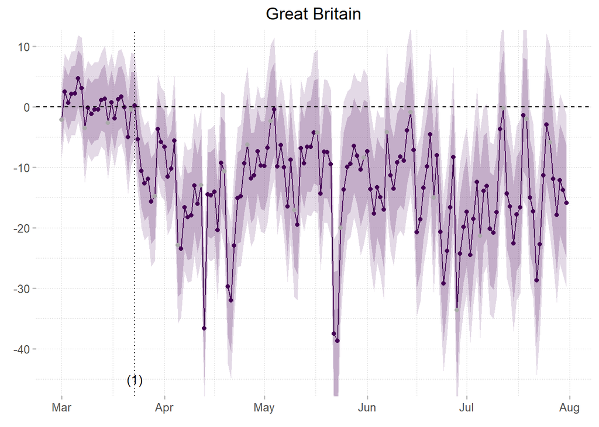

```r
gb_result<- gblist$result
gb_result$lockdown<- as.Date("2020-03-23")

sunday<- gb_result %>% mutate(wday = weekdays(date)) %>% filter(wday == "Sunday")
gbplot<- ggplot(gb_result, aes(date, dif)) +
  geom_ribbon(aes(date, ymin = diflow80, ymax = difup80), fill = viridis_col[1], alpha = .2) +
  geom_ribbon(aes(date, ymin = diflow95, ymax = difup95), fill = viridis_col[1], alpha = .15) +
  geom_line(color = viridis_col[1]) + geom_point(color = viridis_col[1]) +
  geom_hline(yintercept = 0, linetype = "dashed") +
  geom_vline(xintercept = as.Date("2020-03-23"), linetype = "dotted") +
  annotate("text", x = as.Date("2020-03-23"), y = -45, label = "(1)") +
  #annotate("text", x = as.Date("2020-03-02"), y = -33, label = "2.05*", hjust = 0) +
  geom_point(data = sunday, aes(date, dif), color = "darkgrey", size = 1.5) +
  coord_cartesian(ylim = c(-45, 10)) +
  labs(x = element_blank(), y = element_blank(), title = "Great Britain") +
  mytheme() + theme(plot.title = element_text(hjust = 0.5))

write.png(gbplot, "./figures/gb.png")
```

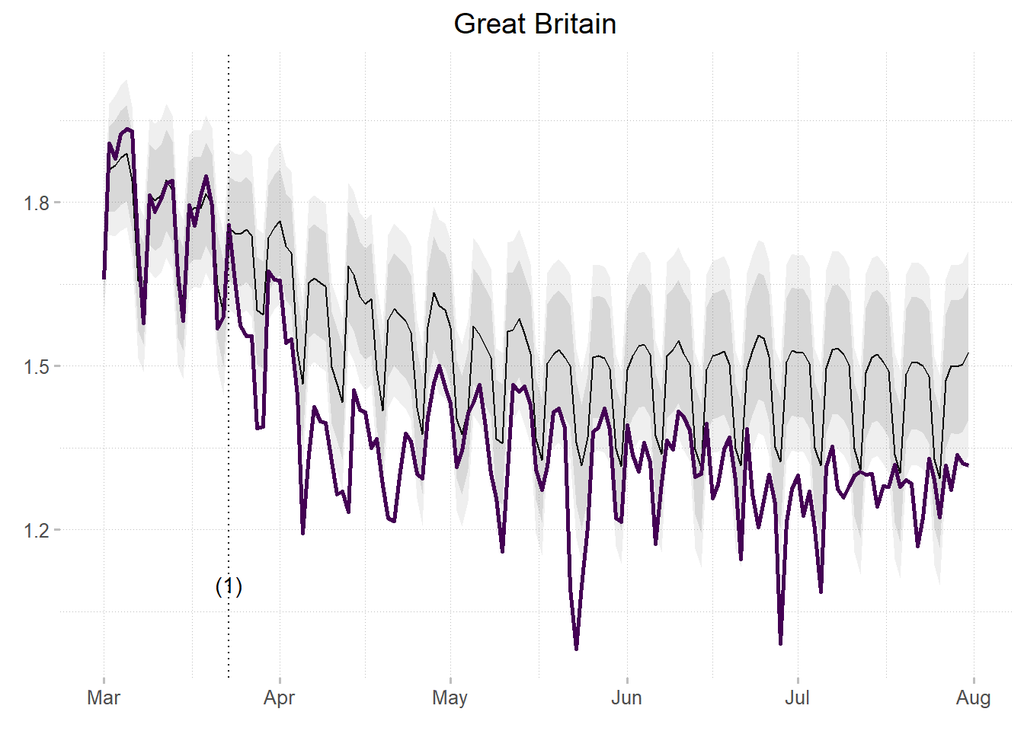

```r
gbplot2<- ggplot(gb_result, aes(date, fct)) +
  geom_line(size = .5) +
  geom_ribbon(aes(date, ymin = low80, ymax = up80), alpha = .12) +
  geom_ribbon(aes(date, ymin = low95, ymax = up95), alpha = .08) +
  geom_line(aes(date, actual),  color = viridis_col[1], size = 1) +
  geom_vline(xintercept = as.Date("2020-03-23"), linetype = "dotted") +
  labs(x = element_blank(), y = element_blank(), title = "Great Britain") +
  annotate("text", x = as.Date("2020-03-23"), y = 1.1, label = "(1)") +
  mytheme() + theme(plot.title = element_text(hjust = 0.5))

write.png(gbplot2, "./figures/gb2.png")
```

```r
############# 4.8 IT ############
get_arima_results(where = "IT", j = 3, k = 20, p = 3, d = 1, q = 1)
```

```
## [1] 20.00  0.98
```

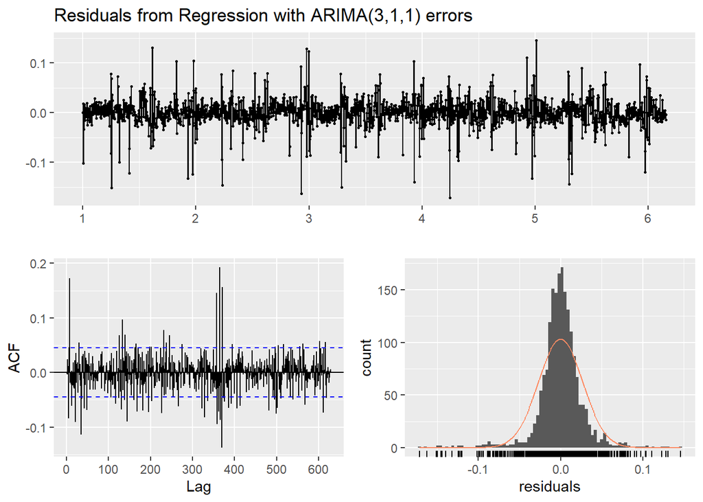

```
##
##  Ljung-Box test
##
## data:  Residuals from Regression with ARIMA(3,1,1) errors
## Q* = 1003.9, df = 324, p-value < 2.2e-16
##
## Model df: 53.   Total lags used: 377
```

```r
itlist<- readRDS("./data/results/forecast_manual/results_IT.rds")

it_fit<- itlist$fit
checkresiduals(it_fit)
```

```r
coeftest(it_fit)
```

```
##
## z test of coefficients:
##
##            Estimate  Std. Error   z value  Pr(>|z|)
## ar1      4.9603e-01  2.5340e-02   19.5753 < 2.2e-16 ***
## ar2     -8.8679e-02  2.6922e-02   -3.2940 0.0009878 ***
## ar3     -7.3771e-02  2.4188e-02   -3.0499 0.0022890 **
## ma1     -9.6483e-01  8.4507e-03 -114.1721 < 2.2e-16 ***
##         -1.6010e-02  4.4063e-04  -36.3342 < 2.2e-16 ***
##          4.7773e-04  2.1662e-05   22.0533 < 2.2e-16 ***
##         -1.0673e-01  3.2364e-03  -32.9767 < 2.2e-16 ***
## S1-7    -1.0162e-01  1.3052e-03  -77.8563 < 2.2e-16 ***
## C1-7     1.8754e-04  1.3049e-03    0.1437 0.8857253
## S2-7    -2.3954e-03  7.0658e-04   -3.3901 0.0006988 ***
## C2-7     5.6160e-02  7.0681e-04   79.4566 < 2.2e-16 ***
## S3-7     2.2181e-02  5.7589e-04   38.5154 < 2.2e-16 ***
## C3-7    -2.1756e-03  5.7584e-04   -3.7781 0.0001580 ***
## S1-365   2.9740e-03  3.3045e-03    0.9000 0.3681199
## C1-365   2.9160e-02  4.6731e-03    6.2400 4.377e-10 ***
## S2-365   5.3369e-03  2.1344e-03    2.5004 0.0124065 *
## C2-365   1.6799e-02  2.0934e-03    8.0249 1.016e-15 ***
## S3-365   6.7646e-03  1.6318e-03    4.1456 3.389e-05 ***
## C3-365  -3.3649e-02  1.5907e-03  -21.1530 < 2.2e-16 ***
## S4-365  -2.2912e-03  1.4745e-03   -1.5539 0.1202191
## C4-365   6.6062e-03  1.4681e-03    4.5000 6.796e-06 ***
## S5-365  -9.8551e-03  1.4152e-03   -6.9635 3.318e-12 ***
## C5-365  -3.0587e-02  1.4132e-03  -21.6433 < 2.2e-16 ***
## S6-365   2.2535e-02  1.3866e-03   16.2512 < 2.2e-16 ***
## C6-365  -9.1360e-03  1.3800e-03   -6.6202 3.588e-11 ***
## S7-365  -8.3589e-03  1.3642e-03   -6.1275 8.927e-10 ***
## C7-365  -8.2790e-03  1.3633e-03   -6.0730 1.256e-09 ***
## S8-365   9.0037e-03  1.3512e-03    6.6635 2.674e-11 ***
## C8-365  -2.1745e-02  1.3548e-03  -16.0506 < 2.2e-16 ***
## S9-365   1.2553e-02  1.3456e-03    9.3292 < 2.2e-16 ***
## C9-365   2.4212e-03  1.3446e-03    1.8007 0.0717486 .
## S10-365 -7.9681e-03  1.3448e-03   -5.9251 3.121e-09 ***
## C10-365 -1.4500e-02  1.3410e-03  -10.8122 < 2.2e-16 ***
## S11-365  1.2921e-02  1.3384e-03    9.6538 < 2.2e-16 ***
## C11-365 -8.4739e-03  1.3398e-03   -6.3249 2.534e-10 ***
## S12-365  5.2613e-03  1.3381e-03    3.9318 8.430e-05 ***
## C12-365 -2.0482e-03  1.3432e-03   -1.5249 0.1272846
## S13-365  2.9070e-03  1.3395e-03    2.1701 0.0299972 *
## C13-365 -1.4351e-02  1.3469e-03  -10.6544 < 2.2e-16 ***
## S14-365  1.1574e-02  1.3415e-03    8.6276 < 2.2e-16 ***
## C14-365  1.5679e-03  1.3447e-03    1.1660 0.2436207
## S15-365 -9.6687e-05  1.3411e-03   -0.0721 0.9425276
## C15-365 -1.1925e-03  1.3429e-03   -0.8880 0.3745656
## S16-365  7.1319e-03  1.3452e-03    5.3018 1.147e-07 ***
## C16-365 -6.1310e-03  1.3458e-03   -4.5555 5.227e-06 ***
## S17-365  1.6095e-03  1.3478e-03    1.1941 0.2324254
## C17-365 -4.7044e-05  1.3495e-03   -0.0349 0.9721914
## S18-365  1.8229e-03  1.3511e-03    1.3492 0.1772867
## C18-365 -9.4433e-04  1.3494e-03   -0.6998 0.4840566
## S19-365  5.4456e-03  1.3567e-03    4.0138 5.974e-05 ***
## C19-365 -3.2369e-03  1.3533e-03   -2.3918 0.0167660 *
## S20-365  3.6767e-03  1.3548e-03    2.7139 0.0066501 **
## C20-365  1.7573e-03  1.3606e-03    1.2916 0.1965118
## ---
## Signif. codes:  0 '***' 0.001 '**' 0.01 '*' 0.05 '.' 0.1 ' ' 1
```

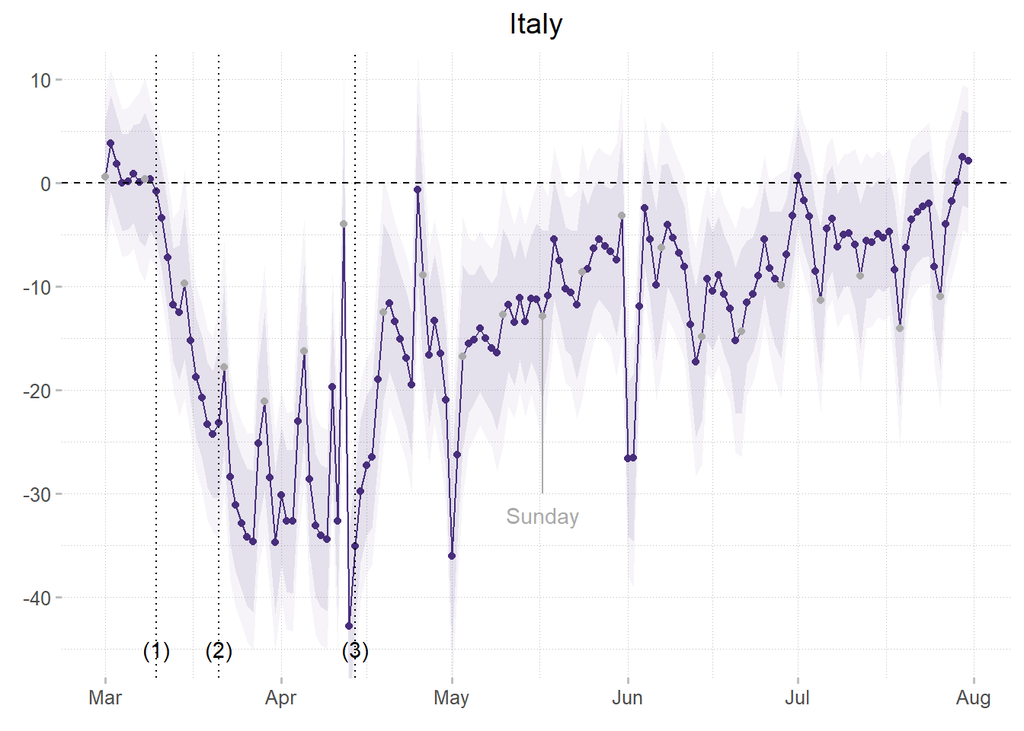

```r
it_result<- itlist$result
it_result$lockdown<-  as.Date("2020-03-10")

sunday<- it_result %>% mutate(wday = weekdays(date)) %>% filter(wday == "Sunday")
itplot<- ggplot(it_result, aes(date, dif)) +
  geom_ribbon(aes(date, ymin = diflow80, ymax = difup80), alpha = .1, fill = viridis_col[2]) +
  geom_ribbon(aes(date, ymin = diflow95, ymax = difup95), alpha = .05, fill = viridis_col[2]) +
  geom_line(color = viridis_col[2]) + geom_point(color = viridis_col[2]) +
  geom_hline(yintercept = 0, linetype = "dashed") +
  geom_vline(xintercept = as.Date("2020-03-10"), linetype = "dotted") +
  geom_vline(xintercept = as.Date("2020-03-21"), linetype = "dotted") +
  geom_vline(xintercept = as.Date("2020-04-14"), linetype = "dotted") +
  annotate("text", x = as.Date("2020-03-10"), y = -45, label = "(1)") +
  annotate("text", x = as.Date("2020-03-21"), y = -45,label = "(2)") +
  annotate("text", x = as.Date("2020-04-14"), y = -45, label = "(3)") +
  #annotate("text", x = as.Date("2020-03-02"), y = -43, label = "2.33*", hjust = 0) +
  geom_segment(aes(x = as.Date("2020-05-17"), y = -13, xend = as.Date("2020-05-17"),
                   yend = -30), color = "darkgrey") +
  annotate("text", x = as.Date("2020-05-17"), y = -32, label = "Sunday",  color = "darkgrey") +
  geom_point(data = sunday, aes(date, dif), color = "darkgrey", size = 1.5) +
  coord_cartesian(ylim = c(-45, 10)) +
  labs(x = element_blank(), y = element_blank(), title = "Italy") +
  mytheme() + theme(plot.title = element_text(hjust = 0.5))

write.png(itplot, "./figures/it.png")
```

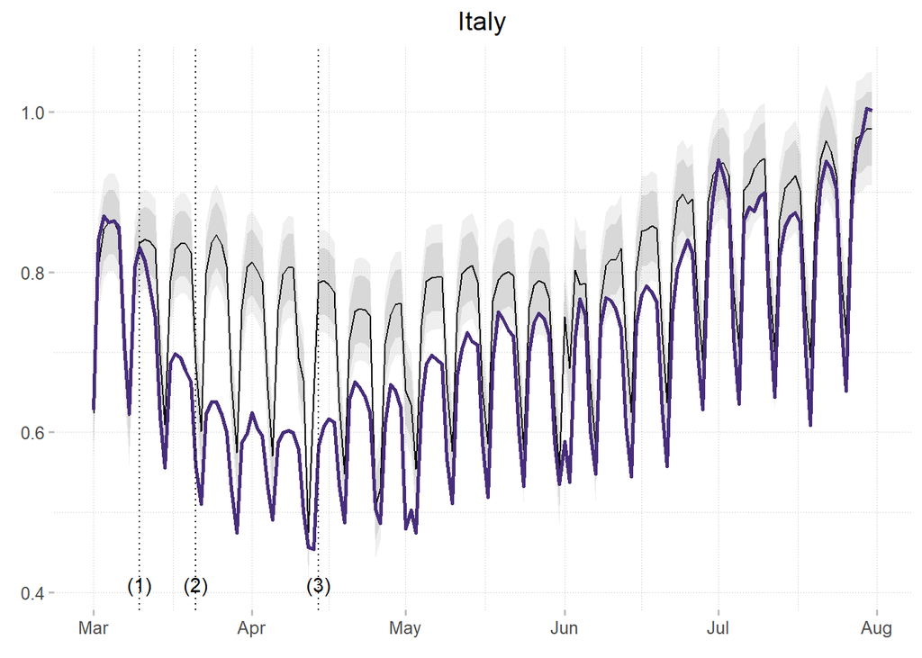

```r
itplot2<- ggplot(it_result, aes(date, fct)) +
  geom_line(size = .5) +
  geom_ribbon(aes(date, ymin = low80, ymax = up80), alpha = .12) +
  geom_ribbon(aes(date, ymin = low95, ymax = up95), alpha = .08) +
  geom_line(aes(date, actual),  color = viridis_col[2], size = 1) +
  geom_vline(xintercept = as.Date("2020-03-10"), linetype = "dotted") +
  geom_vline(xintercept = as.Date("2020-03-21"), linetype = "dotted") +
  geom_vline(xintercept = as.Date("2020-04-14"), linetype = "dotted") +
  annotate("text", x = as.Date("2020-03-10"), y = .41, label = "(1)") +
  annotate("text", x = as.Date("2020-03-21"), y = .41,label = "(2)") +
  annotate("text", x = as.Date("2020-04-14"), y = .41, label = "(3)") +
  labs(x = element_blank(), y = element_blank(), title = "Italy") +
  mytheme() + theme(plot.title = element_text(hjust = 0.5))

write.png(itplot2, "./figures/it2.png")
```

```r
############# 4.9 NY ############
get_arima_results(where = "NY", j = 3, k = 5, p = 3, d = 1, q = 1)
```

```
## [1]  5 -1
```

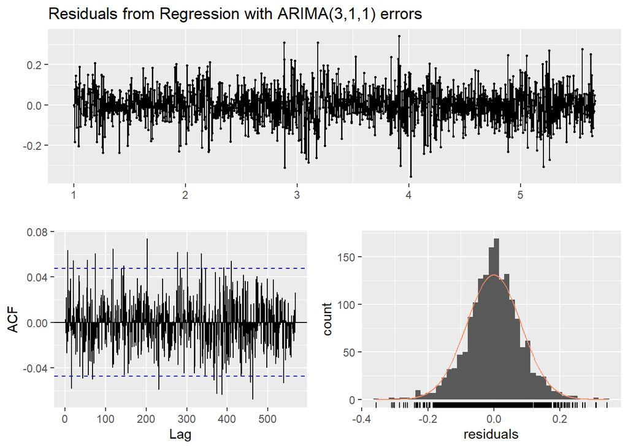

```
##
##  Ljung-Box test
##
## data:  Residuals from Regression with ARIMA(3,1,1) errors
## Q* = 345.96, df = 318, p-value = 0.1348
##
## Model df: 23.   Total lags used: 341
```

```r
nylist<- readRDS("./data/results/forecast_manual/results_NY.rds")


ny_fit<- nylist$fit
checkresiduals(ny_fit)
```

```r
coeftest(ny_fit)
```

```
##
## z test of coefficients:
##
##           Estimate  Std. Error   z value  Pr(>|z|)
## ar1     8.9371e-01  2.8806e-02   31.0251 < 2.2e-16 ***
## ar2    -3.0518e-01  3.3245e-02   -9.1796 < 2.2e-16 ***
## ar3     9.1189e-02  2.4629e-02    3.7025 0.0002135 ***
## ma1    -9.8986e-01  4.3803e-03 -225.9781 < 2.2e-16 ***
##        -1.5062e-02  1.0774e-03  -13.9799 < 2.2e-16 ***
##         5.9601e-04  4.2444e-05   14.0423 < 2.2e-16 ***
##        -7.5494e-02  8.4997e-03   -8.8820 < 2.2e-16 ***
## S1-7    8.7182e-02  4.4291e-03   19.6839 < 2.2e-16 ***
## C1-7    6.9115e-02  4.4392e-03   15.5694 < 2.2e-16 ***
## S2-7   -5.8085e-02  2.2222e-03  -26.1392 < 2.2e-16 ***
## C2-7    2.3226e-02  2.2085e-03   10.5163 < 2.2e-16 ***
## S3-7   -8.4906e-04  1.3178e-03   -0.6443 0.5193952
## C3-7   -2.2147e-02  1.3300e-03  -16.6521 < 2.2e-16 ***
## S1-365  1.0413e-01  1.1044e-02    9.4285 < 2.2e-16 ***
## C1-365  7.6409e-02  1.2981e-02    5.8864 3.948e-09 ***
## S2-365  1.8408e-01  9.5395e-03   19.2965 < 2.2e-16 ***
## C2-365  1.2353e-01  9.4381e-03   13.0883 < 2.2e-16 ***
## S3-365  6.1120e-02  8.9828e-03    6.8041 1.017e-11 ***
## C3-365  1.1021e-02  8.9136e-03    1.2364 0.2163198
## S4-365 -1.2364e-02  8.8343e-03   -1.3996 0.1616395
## C4-365  8.9514e-03  8.8014e-03    1.0170 0.3091341
## S5-365 -7.4716e-03  8.7100e-03   -0.8578 0.3909911
## C5-365  1.6480e-02  8.7155e-03    1.8909 0.0586384 .
## ---
## Signif. codes:  0 '***' 0.001 '**' 0.01 '*' 0.05 '.' 0.1 ' ' 1
```

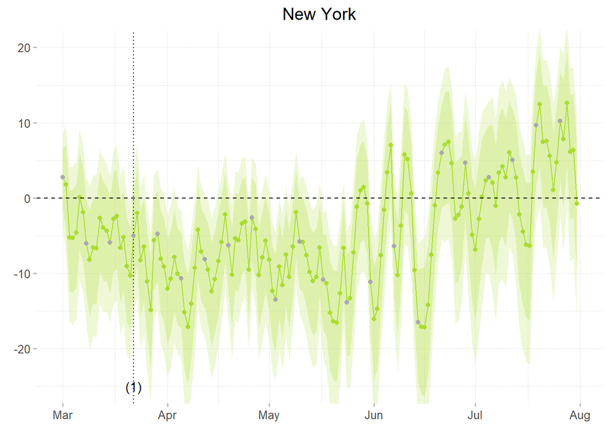

```r
ny_result<- nylist$result
ny_result$lockdown<- as.Date("2020-03-22")

sunday<- ny_result %>% mutate(wday = weekdays(date)) %>% filter(wday == "Sunday")
nyplot<- ggplot(ny_result, aes(date, dif)) +
  geom_ribbon(aes(date, ymin = diflow80, ymax = difup80), fill = viridis_col[8], alpha = .25) +
  geom_ribbon(aes(date, ymin = diflow95, ymax = difup95), fill = viridis_col[8], alpha = .2) +
  geom_line(color = viridis_col[8]) + geom_point(color = viridis_col[8]) +
  geom_hline(yintercept = 0, linetype = "dashed") +
  geom_vline(xintercept = as.Date("2020-03-22"), linetype = "dotted") +
  annotate("text", x = as.Date("2020-03-22"), y = -25, label = "(1)") +
  #annotate("text", x = as.Date("2020-03-02"), y = -32, label = "1.63*", hjust = 0) +
  geom_point(data = sunday, aes(date, dif), color = "darkgrey", size = 1.5) +
  coord_cartesian(ylim = c(-25, 20)) +
  labs(x = element_blank(), y = element_blank(), title = "New York") +
  mytheme() + theme(plot.title = element_text(hjust = 0.5))

write.png(nyplot, "./figures/ny.png")
```

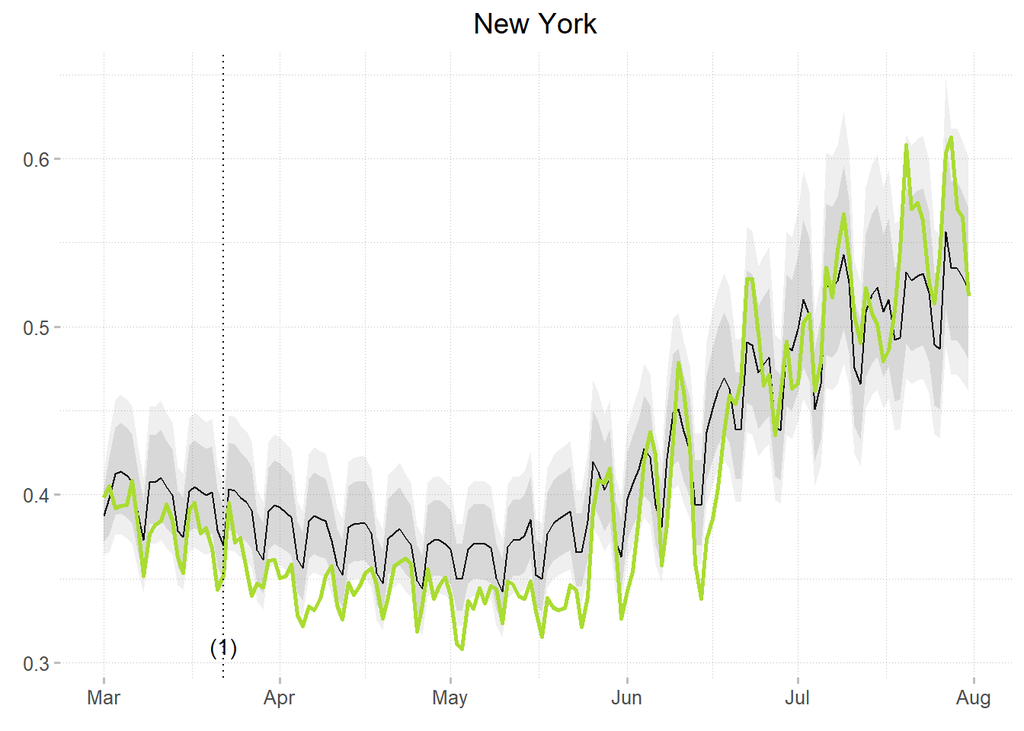

```r
nyplot2<- ggplot(ny_result, aes(date, fct)) +
  geom_line(size = .5) +
  geom_ribbon(aes(date, ymin = low80, ymax = up80), alpha = .12) +
  geom_ribbon(aes(date, ymin = low95, ymax = up95), alpha = .08) +
  geom_line(aes(date, actual),  color = viridis_col[8], size = 1) +
  geom_vline(xintercept = as.Date("2020-03-22"), linetype = "dotted") +
  labs(x = element_blank(), y = element_blank(), title = "New York") +
  annotate("text", x = as.Date("2020-03-22"), y = .31, label = "(1)") +
  mytheme() + theme(plot.title = element_text(hjust = 0.5))

write.png(nyplot2, "./figures/ny2.png")
```

# Cumulative electricity decline

After calculating the difference in electricity consumption with respect to the baseline, we can calculate the cumulative decline by country.

```r
atc<- at_result %>% filter(date >= "2020-03-15") %>% mutate(t = 0:(length(date)-1))
cac<- ca_result %>% filter(date >= "2020-03-18") %>% mutate(t = 0:(length(date)-1))
dec<- de_result %>% filter(date >= "2020-03-21") %>% mutate(t = 0:(length(date)-1))
esc<- es_result %>% filter(date >= "2020-03-13") %>% mutate(t = 0:(length(date)-1))
flc<- fl_result %>% filter(date >= "2020-04-02") %>% mutate(t = 0:(length(date)-1))
frc<- fr_result %>% filter(date >= "2020-03-16") %>% mutate(t = 0:(length(date)-1))
gbc<- gb_result %>% filter(date >= "2020-03-22") %>% mutate(t = 0:(length(date)-1))
itc<- it_result %>% filter(date >= "2020-03-09") %>% mutate(t = 0:(length(date)-1))
nyc<- ny_result %>% filter(date >= "2020-03-21") %>% mutate(t = 0:(length(date)-1))

cum_results<- bind_rows(atc, cac, dec, esc, flc, frc, gbc, itc, nyc) %>%
  arrange(country, t) %>% select(country, t, date, actual, fct, dif) %>%
  group_by(country) %>%
  mutate(index = 100*cumsum(actual)/cumsum(fct),
         index = ifelse(t == 0, 100, index),
         index_pc = index-100)

saveRDS(cum_results, "./data/results/cum_results.rds")
cum_results<- readRDS("./data/results/cum_results.rds")

legend<- cum_results %>% summarize(t = max(t), index = last(index), index_pc = last(index_pc))
legend %>% arrange(index_pc)
```

```
## # A tibble: 9 x 4
##   country     t index index_pc
##   <chr>   <int> <dbl>    <dbl>
## 1 GB        131  88.6  -11.4
## 2 IT        144  89.0  -11.0
## 3 FR        137  91.2   -8.82
## 4 ES        140  91.4   -8.56
## 5 DE        132  92.5   -7.50
## 6 CA        135  95.3   -4.68
## 7 AT        138  95.4   -4.58
## 8 NY        132  96.7   -3.26
## 9 FL        120 101.     0.867
```

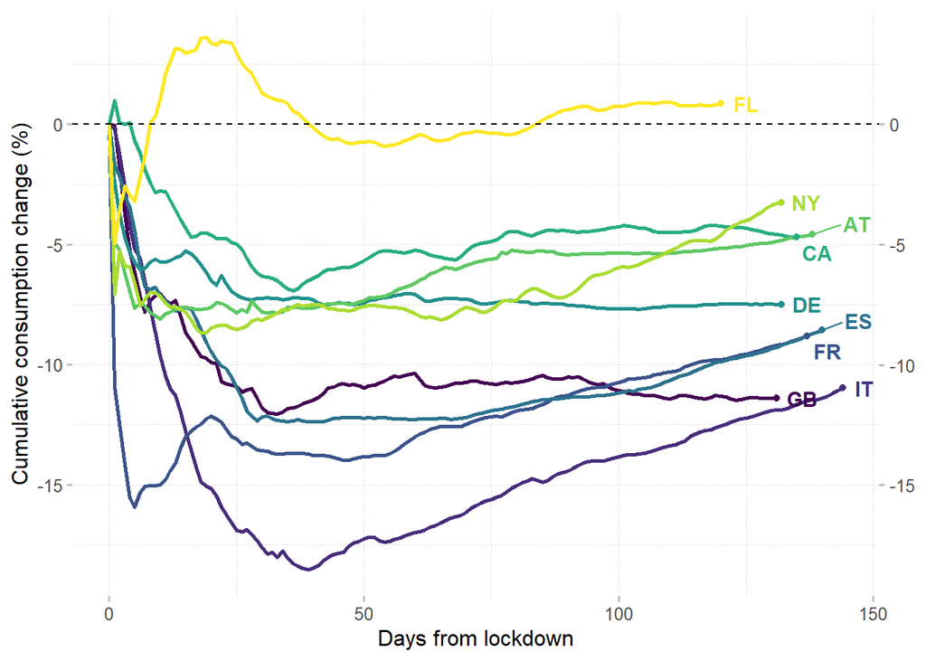

```r
my_colors <- RColorBrewer::brewer.pal(4, "Blues")[2:4]

cumplot<- ggplot(cum_results, aes(t, index_pc, color = fct_reorder(country, index, .fun='last'))) +
  geom_line(size = 1, alpha = 1.5) +
  geom_point(data = legend, aes(x = t, y = index_pc)) +
  geom_hline(yintercept = 0, linetype = "dashed") +
  geom_text_repel(data = legend, aes(x = t, y = index_pc, label = country),
            nudge_x = 5, size = 4, fontface = "bold") +
  scale_color_viridis_d() +
  scale_y_continuous(sec.axis = sec_axis(~ .)) +
  labs(x = "Days from lockdown", y = "Cumulative consumption change (%)") +
  mytheme() + theme(legend.position = "none")

write.png(cumplot, "./figures/cumulative.png")
```

# Stringency

Finally, the relationship between measures stringency and electricity consumption decline is calculated as follows:

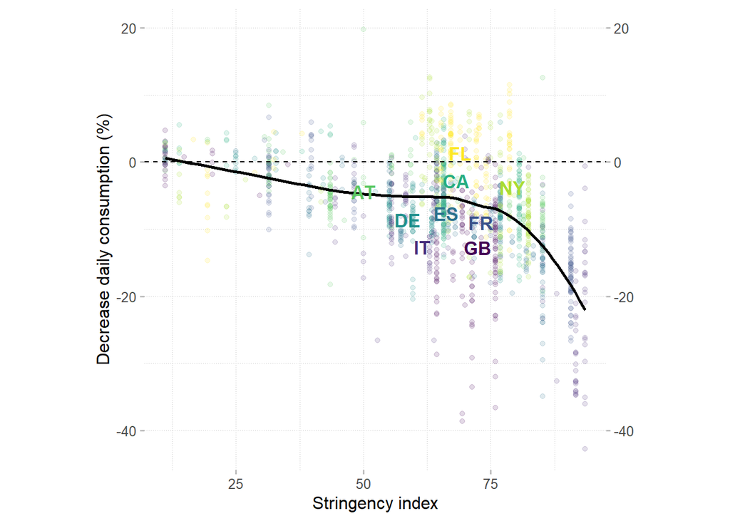

```r
# import and clean country- and state-level stringency data
stringencyEU<- read.csv("./data/raw/stringency/OxCGRT_latest.csv") %>%
  select(country = CountryName, date = Date, school = C1_School.closing, school_general = C1_Flag,
         workplace = C2_Workplace.closing, workplace_general = C2_Flag,
         events = C3_Cancel.public.events, events_general = C3_Flag,
         transport = C5_Close.public.transport, transport_general = C5_Flag,
         stayhome = C6_Stay.at.home.requirements, stayhome_general = C6_Flag,
         movement = C7_Restrictions.on.internal.movement, movement_general = C7_Flag,
         travel = C8_International.travel.controls,
         index = StringencyIndex) %>%
  filter(country %in% c("Germany", "Spain", "Italy", "France", "Austria", "United Kingdom")) %>%
  droplevels() %>%
  mutate(country = as.factor(country),
         date = ymd(date),
         school = as.factor(replace_na(ifelse(school_general == 1 & school == 3, 1, 0), 0)),
         workplace = as.factor(replace_na(ifelse(workplace_general == 1 & workplace == 3, 1, 0), 0)),
         events = as.factor(replace_na(ifelse(events_general == 1 & events == 2, 1, 0), 0)),
         transport = as.factor(replace_na(ifelse(transport_general == 1 & transport == 2, 1, 0), 0)),
         stayhome = as.factor(replace_na(ifelse(transport_general == 1 & stayhome == 3, 1, 0), 0)),
         movement = as.factor(replace_na(ifelse(movement_general == 1 & movement == 2, 1, 0), 0)),
         travel = as.factor(replace_na(ifelse(travel == 4, 1, 0), 0))) %>%
  select(country, date, school, workplace, events, transport, movement, travel, index) %>%
  arrange(country, date) %>% as_tibble()

stringencyEU$country<- plyr::mapvalues(stringencyEU$country,
              from = c("Germany", "Spain", "Italy", "France", "Austria", "United Kingdom"),
              to = c("DE", "ES", "IT", "FR", "AT", "GB"))


stringencyUS<- read.csv("./data/raw/stringency/OxCGRT_US_states_temp.csv") %>%
  select(country = RegionName, date = Date, school = C1_School.closing, school_general = C1_Flag,
         workplace = C2_Workplace.closing, workplace_general = C2_Flag,
         events = C3_Cancel.public.events, events_general = C3_Flag,
         transport = C5_Close.public.transport, transport_general = C5_Flag,
         stayhome = C6_Stay.at.home.requirements, stayhome_general = C6_Flag,
         movement = C7_Restrictions.on.internal.movement, movement_general = C7_Flag,
         travel = C8_International.travel.controls,
         index = StringencyIndex) %>%
  filter(country %in% c("California", "New York", "Florida")) %>%
  droplevels() %>%
  mutate(country = as.factor(country),
         date = ymd(date),
         school = as.factor(replace_na(ifelse(school_general == 1 & school == 3, 1, 0), 0)),
         workplace = as.factor(replace_na(ifelse(workplace_general == 1 & workplace == 3, 1, 0), 0)),
         events = as.factor(replace_na(ifelse(events_general == 1 & events == 2, 1, 0), 0)),
         transport = as.factor(replace_na(ifelse(transport_general == 1 & transport == 2, 1, 0), 0)),
         stayhome = as.factor(replace_na(ifelse(transport_general == 1 & stayhome == 3, 1, 0), 0)),
         movement = as.factor(replace_na(ifelse(movement_general == 1 & movement == 2, 1, 0), 0)),
         travel = as.factor(replace_na(ifelse(travel == 4, 1, 0), 0))) %>%
  select(country, date, school, workplace, events, transport, movement, travel, index) %>%
  arrange(country, date) %>% as_tibble()

stringencyUS$country<- plyr::mapvalues(stringencyUS$country,
              from = c("California", "Florida", "New York"),
              to = c("CA", "FL", "NY"))

stringency<- bind_rows(stringencyEU, stringencyUS)
# import consumption data
dif_results<- readRDS("./data/results/dif_results.rds") %>%
  select(country, date, dif) %>% mutate(country = as.factor(country))

# merge data
str_data<- right_join(dif_results, stringency, by = c("country", "date")) %>%
  mutate(country = as.factor(country)) %>% na.omit() %>% droplevels()
# median for country labels
medpoint<- str_data %>% group_by(country) %>%
  summarise(dif = median(dif), index = median(index))

# color palette
# order: AT, CA, DE, ES, FL, \newline FR, GB, IT, NY
mycolors = c(viridis_col[7], viridis_col[6],viridis_col[5], viridis_col[4], viridis_col[9],
             viridis_col[3], viridis_col[1], viridis_col[2], viridis_col[8])

# plot
strindexplot<- ggplot(str_data, aes(index, dif)) +
  geom_point(aes(color = country), alpha = .15) +
  geom_hline(yintercept = 0, color = "black", linetype = "dashed") +
  geom_smooth(method = loess, se = F, color = "black", size = 1) +
  geom_text_repel(data = medpoint, aes(x = index, y = dif, color = country, label = country),
            fontface = "bold", size = 4.5, force = .01) +
  scale_color_manual(values = mycolors) +
  scale_y_continuous(sec.axis = sec_axis(~ .)) +
  labs(x = "Stringency index", y = "Decrease daily consumption (%)") +
  mytheme() + theme(aspect.ratio = 1, legend.position = "none")

write.png(strindexplot, "./figures/stringency_index.png", width=5, height=5)
```